# Capstone: Loan Default Prediction

[figure not shown]

# Problem Overview

The bank wants to improve its loan approval process by predicting customers likely to default on home equity loans. A machine learning model must be developed to automate this process, ensuring it is free from biases and interpretable enough for regulatory purposes.

**Project Objectives:**

- Build a classification model to predict loan defaults.
- Identify key factors influencing loan defaults.
- Ensure the model is interpretable for decision-making.
- Provide recommendations for improving the loan approval process.
- Ensure fairness and compliance with regulatory guidelines.

# Index

- Load Essential Libraries
- Load Dataset and Data Overview
- Exploratory Data Analytics
- Data Pre-processing
- Model Building Approach
- Model Building
- Model Comparison and Selection
- Insights and Recommendations

# Load Essential Libraries

```python
# Libraries for Data Manipulation and Numerical Operations
import numpy as np  # For numerical operations
import pandas as pd  # For data manipulation

# Set pandas display options for better readability of output
pd.set_option("display.max_columns", None)
pd.set_option("display.max_rows", 200)

# Libraries for Data Visualization
import matplotlib.pyplot as plt  # For plotting
import seaborn as sns  # For enhanced visualizations
from matplotlib.colors import LinearSegmentedColormap # For Custom Segmented Color Maps

# Set Seaborn aesthetic parameters
sns.set(
    context='notebook',
    style='darkgrid',
    font='sans-serif',
    font_scale=0.8,
    rc={'figure.figsize': (20, 14)}
)

# Libraries from Statsmodel
from statsmodels.stats.outliers_influence import variance_inflation_factor # For Multicollinearity Check

# Libraries for Sci-Kit Learn
from sklearn.impute import KNNImputer, SimpleImputer # For imputing missing values
from sklearn.model_selection import train_test_split, GridSearchCV, RandomizedSearchCV # For spliting data in Train and Test set and performance tuning
from sklearn.preprocessing import StandardScaler, OneHotEncoder # For scalling the dataset and encoding categorical columns
from sklearn.linear_model import LogisticRegression
from sklearn.metrics import accuracy_score, precision_score, recall_score, f1_score, roc_auc_score, confusion_matrix, make_scorer
from sklearn.discriminant_analysis import LinearDiscriminantAnalysis
from sklearn.tree import DecisionTreeClassifier
from sklearn.ensemble import RandomForestClassifier, AdaBoostClassifier, GradientBoostingClassifier
from sklearn.neighbors import KNeighborsClassifier
from xgboost import XGBClassifier
from sklearn import metrics

# Library to resample data
from imblearn.over_sampling import SMOTE # for resampling data using Synthetic Minority Over-sampling Technique

# Libraries for Displaying Data in Notebooks
from IPython.display import display, HTML

import locale

# Set the locale for currency formatting (this example uses US locale, change to your preference)
locale.setlocale(locale.LC_ALL, 'en_US.UTF-8')

# Ignore warnings to keep the output clean
import warnings
warnings.filterwarnings("ignore")
```

# Load Dataset and Data Overview

```python
# Load Dataset
path = '/content/drive/MyDrive/Colab Notebooks/06-Capstone/hmeq.csv'
df_hmeq = pd.read_csv(path)
```

```python
# Display the first few rows of the dataset
df_hmeq.head()
```

|  | BAD | LOAN | MORTDUE | VALUE | REASON | JOB | YOJ | DEROG | DELINQ | CLAGE | NINQ | CLNO | DEBTINC |
| --- | --- | --- | --- | --- | --- | --- | --- | --- | --- | --- | --- | --- | --- |
| 0 | 1 | 1100 | 25860.0 | 39025.0 | HomeImp | Other | 10.5 | 0.0 | 0.0 | 94.366667 | 1.0 | 9.0 | NaN |
| 1 | 1 | 1300 | 70053.0 | 68400.0 | HomeImp | Other | 7.0 | 0.0 | 2.0 | 121.833333 | 0.0 | 14.0 | NaN |
| 2 | 1 | 1500 | 13500.0 | 16700.0 | HomeImp | Other | 4.0 | 0.0 | 0.0 | 149.466667 | 1.0 | 10.0 | NaN |
| 3 | 1 | 1500 | NaN | NaN | NaN | NaN | NaN | NaN | NaN | NaN | NaN | NaN | NaN |
| 4 | 0 | 1700 | 97800.0 | 112000.0 | HomeImp | Office | 3.0 | 0.0 | 0.0 | 93.333333 | 0.0 | 14.0 | NaN |

```python
# Display the last few rows of the dataset
df_hmeq.tail()
```

|  | BAD | LOAN | MORTDUE | VALUE | REASON | JOB | YOJ | DEROG | DELINQ | CLAGE | NINQ | CLNO | DEBTINC |
| --- | --- | --- | --- | --- | --- | --- | --- | --- | --- | --- | --- | --- | --- |
| 5955 | 0 | 88900 | 57264.0 | 90185.0 | DebtCon | Other | 16.0 | 0.0 | 0.0 | 221.808718 | 0.0 | 16.0 | 36.112347 |
| 5956 | 0 | 89000 | 54576.0 | 92937.0 | DebtCon | Other | 16.0 | 0.0 | 0.0 | 208.692070 | 0.0 | 15.0 | 35.859971 |
| 5957 | 0 | 89200 | 54045.0 | 92924.0 | DebtCon | Other | 15.0 | 0.0 | 0.0 | 212.279697 | 0.0 | 15.0 | 35.556590 |
| 5958 | 0 | 89800 | 50370.0 | 91861.0 | DebtCon | Other | 14.0 | 0.0 | 0.0 | 213.892709 | 0.0 | 16.0 | 34.340882 |
| 5959 | 0 | 89900 | 48811.0 | 88934.0 | DebtCon | Other | 15.0 | 0.0 | 0.0 | 219.601002 | 0.0 | 16.0 | 34.571519 |

```python
# Check the Dataset Shape
print(f'The dataset has {df_hmeq.shape[0]} rows and {df_hmeq.shape[1]} columns.')
```

```
The dataset has 5960 rows and 13 columns.
```

```python
# Display Dataset Information
df_hmeq.info()
```

```
<class 'pandas.core.frame.DataFrame'>
RangeIndex: 5960 entries, 0 to 5959
Data columns (total 13 columns):
 #   Column   Non-Null Count  Dtype
---  ------   --------------  -----
 0   BAD      5960 non-null   int64
 1   LOAN     5960 non-null   int64
 2   MORTDUE  5442 non-null   float64
 3   VALUE    5848 non-null   float64
 4   REASON   5708 non-null   object
 5   JOB      5681 non-null   object
 6   YOJ      5445 non-null   float64
 7   DEROG    5252 non-null   float64
 8   DELINQ   5380 non-null   float64
 9   CLAGE    5652 non-null   float64
 10  NINQ     5450 non-null   float64
 11  CLNO     5738 non-null   float64
 12  DEBTINC  4693 non-null   float64
dtypes: float64(9), int64(2), object(2)
memory usage: 605.4+ KB
```

**Observations:**

- The dataset contains **5960 rows** and **13 columns**.
- The target variable (`BAD`) has no missing values (5960 non-null).
- **Missing values** are present in several columns, further checks are required
- **Numerical columns**: 9 columns of type `float64` and 2 columns of type `int64`.
- **Categorical columns**: 2 columns of type `object` (`REASON`, `JOB`).
- The dataset uses approximately **605.4 KB** of memory.

```python
# Data Statistics for Numerical Values
df_hmeq.describe(include='number').T
```

|  | count | mean | std | min | 25% | 50% | 75% | max |
| --- | --- | --- | --- | --- | --- | --- | --- | --- |
| BAD | 5960.0 | 0.199497 | 0.399656 | 0.000000 | 0.000000 | 0.000000 | 0.000000 | 1.000000 |
| LOAN | 5960.0 | 18607.969799 | 11207.480417 | 1100.000000 | 11100.000000 | 16300.000000 | 23300.000000 | 89900.000000 |
| MORTDUE | 5442.0 | 73760.817200 | 44457.609458 | 2063.000000 | 46276.000000 | 65019.000000 | 91488.000000 | 399550.000000 |
| VALUE | 5848.0 | 101776.048741 | 57385.775334 | 8000.000000 | 66075.500000 | 89235.500000 | 119824.250000 | 855909.000000 |
| YOJ | 5445.0 | 8.922268 | 7.573982 | 0.000000 | 3.000000 | 7.000000 | 13.000000 | 41.000000 |
| DEROG | 5252.0 | 0.254570 | 0.846047 | 0.000000 | 0.000000 | 0.000000 | 0.000000 | 10.000000 |
| DELINQ | 5380.0 | 0.449442 | 1.127266 | 0.000000 | 0.000000 | 0.000000 | 0.000000 | 15.000000 |
| CLAGE | 5652.0 | 179.766275 | 85.810092 | 0.000000 | 115.116702 | 173.466667 | 231.562278 | 1168.233561 |
| NINQ | 5450.0 | 1.186055 | 1.728675 | 0.000000 | 0.000000 | 1.000000 | 2.000000 | 17.000000 |
| CLNO | 5738.0 | 21.296096 | 10.138933 | 0.000000 | 15.000000 | 20.000000 | 26.000000 | 71.000000 |
| DEBTINC | 4693.0 | 33.779915 | 8.601746 | 0.524499 | 29.140031 | 34.818262 | 39.003141 | 203.312149 |

**Observations:**

- **BAD**: ~20% of the applicants defaulted (mean = 0.199), and it's a binary variable (0 or 1).
- **LOAN**: The average loan amount is \$18,607, with a large range (min = \$1,100, max = \$89,900).
- **MORTDUE**: Mortgage due varies widely (mean = \$73,760, max = \$399,550), indicating a diverse borrower pool.
- **VALUE**: Property values range significantly (mean = \$101,776, max = \$855,909), with 25th percentile at \$66,075 and 75th at \$119,824.
- **YOJ (Years on Job)**: Median is 7 years, suggesting stability; however, some applicants have very low job tenure (min = 0).
- **DEROG and DELINQ**: Most applicants have no derogatory reports or delinquencies (75th percentile = 0).
- **CLAGE**: Credit age is quite high on average (mean = ~179 months), indicating experienced credit users.
- **NINQ (Credit Inquiries)**: Most applicants have fewer recent credit inquiries (median = 1, max = 17).
- **CLNO (Credit Lines)**: The average number of credit lines is 21, with a wide spread (min = 0, max = 71).
- **DEBTINC**: The debt-to-income ratio has a mean of 33.78%, but some applicants have extremely high ratios (max = 203.31%), which could indicate financial stress.

```python
# Statistics for Categorical Values
df_hmeq.describe(include='object').T
```

|  | count | unique | top | freq |
| --- | --- | --- | --- | --- |
| REASON | 5708 | 2 | DebtCon | 3928 |
| JOB | 5681 | 6 | Other | 2388 |

**Observations:**

- **REASON**: The majority of applicants (3928 out of 5708) applied for loans due to **Debt Consolidation**, with **2 unique categories**.
- **JOB**: The most common job category is **Other** (2388 out of 5681), with **6 unique job categories** in total.

```python
# Check for Duplicates
df_hmeq.duplicated().sum()
```

```
0
```

**Observations:**

- There are no duplicate records.

```python
# Check for Missing Values
df_hmeq_missing = df_hmeq.isna().sum()[df_hmeq.isnull().sum() > 0]  # Get count of missing values
df_hmeq_missing = df_hmeq_missing.to_frame(name='missing_count').rename_axis('Column_name')  # Convert series to DataFrame
df_hmeq_missing['percentage'] = round(df_hmeq_missing['missing_count'] / len(df_hmeq) * 100, 2)  # Calculate percentage
df_hmeq_missing.sort_values(by=df_hmeq_missing.columns[1], ascending=False, inplace=True)  # Sort by percentage, highest first
df_hmeq_missing
```

| Column_name | missing_count | percentage |
| --- | --- | --- |
| DEBTINC | 1267 | 21.26 |
| DEROG | 708 | 11.88 |
| DELINQ | 580 | 9.73 |
| MORTDUE | 518 | 8.69 |
| YOJ | 515 | 8.64 |
| NINQ | 510 | 8.56 |
| CLAGE | 308 | 5.17 |
| JOB | 279 | 4.68 |
| REASON | 252 | 4.23 |
| CLNO | 222 | 3.72 |
| VALUE | 112 | 1.88 |

**Observations on Missing Data:**

- Several features contain missing values, with **DEBTINC** having the highest proportion at **21.26%**, followed by **DEROG** and **DELINQ** with **11.88%** and **9.73%**, respectively.
- Features like **MORTDUE**, **YOJ**, and **NINQ** also have moderate levels of missing data, ranging from **8.69%** to **8.56%**.
- Missing data could impact the model’s predictive power if not handled properly, especially in features crucial for loan default prediction.
- We will explore options to appropriately impute both numerical and categorical missing values during Data Pre-Processing stage.

# Exploratory Data Analysis (EDA)

- Univariate Analysis - Numerical Features
- Univariate Analysis - Categorical Features
- Bivariate Analysis - Numerical Features vs Target Variable (BAD)
- Bivariate Analysis - Categorical Features vs Target Variable (BAD)
- Multivariate Analysis - Correlation Heatmap (Numerical Features)
- EDA Summary and Key Insights

## Functions to aide EDA

```python
import math

# Plots boxplots and histograms for numerical features of a DataFrame.
def plot_numerical(dataframe, target_variable=None):

    # Extract numerical variables
    if target_variable:
        numeric_columns = dataframe.select_dtypes(include=['float64', 'int64']).drop(target_variable, axis=1).columns
    else:
        numeric_columns = dataframe.select_dtypes(include=['float64', 'int64']).columns
    num_vars = len(numeric_columns)

    # Calculate the number of rows for the subplot
    num_rows = (num_vars // 4) + (1 if num_vars % 4 != 0 else 0)

    # Set up the matplotlib figure
    fig, axes = plt.subplots(2 * num_rows, 4, figsize=(20, 4 * num_rows * 1.25), constrained_layout=True, gridspec_kw={'height_ratios': [1, 4] * num_rows})

    # Loop through the numerical variables to create boxplots and histograms
    for i, column in enumerate(numeric_columns):
        # Define the row and column index in the subplot grid
        row = (i // 4) * 2
        col = i % 4

        # Create a boxplot for the variable
        sns.boxplot(data=dataframe, x=column, ax=axes[row, col])
        axes[row, col].set_title(f'Box Plot and Histogram for {column}', fontsize=12)
        axes[row, col].tick_params(labelbottom=False)  # Remove x-ticks for the boxplot
        axes[row, col].set_xlabel('')  # Remove x-axis label for the boxplot

        # Create a histogram for the variable
        sns.histplot(data=dataframe, x=column, kde=True, ax=axes[row + 1, col], binwidth=None)
        axes[row + 1, col].set_title('')  # Remove title for the histogram
        axes[row + 1, col].set_xlabel(f'{column}\n\n')  # Set x-axis label for the histogram

    # Remove the excess axes
    i += 1
    delrow =  (i // 4) * 2
    delcol = i % 4
    fig.delaxes(axes[delrow, delcol])
    fig.delaxes(axes[delrow, delcol + 1])
    fig.delaxes(axes[delrow + 1, delcol])
    fig.delaxes(axes[delrow + 1, delcol + 1])

    plt.show()

# Display bar plots for categorical features
def plot_categorical_bars(data):
    """
    Plots bar plots for all categorical columns in the DataFrame.

    Parameters:
        data (DataFrame): The pandas DataFrame containing the data.
    """
    # Identify categorical columns: Either by dtype 'object' or by checking the number of unique values
    categorical_columns = [col for col in data.columns if data[col].dtype == 'object']

    # Set the number of columns for subplot grid
    ncols = 2 if len(categorical_columns) > 2 else len(categorical_columns)
    nrows = (len(categorical_columns) + ncols - 1) // ncols  # Calculate the number of rows needed

    # Set dynamic width of the figure based on the number of columns
    fig_width = 20  # Each subplot approx 5 inches wide
    fig_height = 8 * nrows  # Each subplot approx 5 inches tall

    fig, axes = plt.subplots(nrows=nrows, ncols=ncols, figsize=(fig_width, fig_height))
    axes = axes.flatten() if nrows > 1 or ncols > 1 else [axes]  # Handle the case of a single subplot

    # Loop over the categorical columns and create a bar plot for each
    for i, col in enumerate(categorical_columns):
        sns.countplot(x=col, data=data, ax=axes[i])
        axes[i].set_title(f'Bar Plot of {col}', fontsize=12)
        axes[i].set_xlabel('')
        axes[i].set_ylabel('Count')
        axes[i].tick_params(axis='x', rotation=45)  # Rotate x-axis labels

    # Hide unused subplots if any
    for j in range(i + 1, len(axes)):
        axes[j].set_visible(False)

    plt.tight_layout()
    plt.show()

# Use Top 10 correlated features to target column (Default), evaluate each with the target column
def plot_boxplots(features_df, target_series):
    """
    Parameters:
    - features_df: pandas DataFrame containing the numerical features
    - target_series: pandas Series containing the target variable
    """
    # Get column names of the features
    numeric_cols = features_df.columns

    # Number of numerical features
    num_features = len(numeric_cols)
    num_rows = (num_features + 3) // 3  # Calculate the number of rows needed for subplots

    # Set the figure size based on the number of rows
    plt.figure(figsize=(20, 5 * num_rows))

    # Loop through each numerical column and create a boxplot against the target variable
    for i, col in enumerate(numeric_cols, 1):
        plt.subplot(num_rows, 3, i)
        sns.boxplot(x=target_series, y=features_df[col])
        plt.title(f'{col} vs Default (Target)', fontsize=12)

    plt.tight_layout()
    plt.show()

# Use Top 10 categorical features to evaluate each with the target column (Default)
def plot_stacked_barcharts(features_df, target_series):
    """
    Parameters:
    - features_df: pandas DataFrame containing the categorical features
    - target_series: pandas Series containing the target variable
    """
    # Get column names of the categorical features
    categorical_cols = features_df.columns

    # Create a gradient colormap from white to steelblue
    steelblue_gradient = LinearSegmentedColormap.from_list("steelblue_gradient", ['lightsteelblue', 'steelblue'])

    # Number of categorical features
    num_features = len(categorical_cols)
    num_rows = (num_features + 2) // 3  # Calculate the number of rows needed for subplots (3 per row)

    # Set the figure size based on the number of rows
    plt.figure(figsize=(20, 5 * num_rows))

    # Loop through each categorical column and create a stacked bar chart against the target variable
    for i, col in enumerate(categorical_cols, 1):
        plt.subplot(num_rows, 3, i)

        # Create a crosstab for the relationship between the categorical feature and the target
        crosstab = pd.crosstab(features_df[col], target_series)

        # Plot the stacked bar chart
        crosstab.plot(kind='bar', stacked=True, ax=plt.gca(), colormap=steelblue_gradient)

        # Set title and labels
        plt.title(f'{col} vs Default (Target)', fontsize=12)
        plt.ylabel('Proportion')
        plt.xlabel(col)

    plt.tight_layout()
    plt.show()

# Generate a correlation matrix for numerical features
def plot_correlation_heatmap(data):
    # Filter out only numerical columns
    numeric_data = data.select_dtypes(include=['float64', 'int64'])

    # Calculate the correlation matrix
    corr_matrix = numeric_data.corr()

    # Create the heatmap
    plt.figure(figsize=(12, 8))
    sns.heatmap(corr_matrix, annot=True, cmap='coolwarm', fmt='.2f', linewidths=0.5)

    # Add a title
    plt.title('Correlation Heatmap', fontsize=16)

    # Display the plot
    plt.show()

# Function to calculate VIF for numerical features
def calculate_vif(data):
    # Filter out only numerical columns
    numeric_data = data.select_dtypes(include=['float64', 'int64']).dropna()

    # Add a constant for the regression model
    X = numeric_data.assign(const=1)

    # Create an empty DataFrame to store VIF values
    vif_data = pd.DataFrame()
    vif_data['Feature'] = X.columns

    # Calculate VIF for each feature
    vif_data['VIF'] = [variance_inflation_factor(X.values, i) for i in range(X.shape[1])]

    # Return VIF excluding the constant term
    return vif_data[vif_data['Feature'] != 'const']
```

## Univariate Analysis - Numerical Values

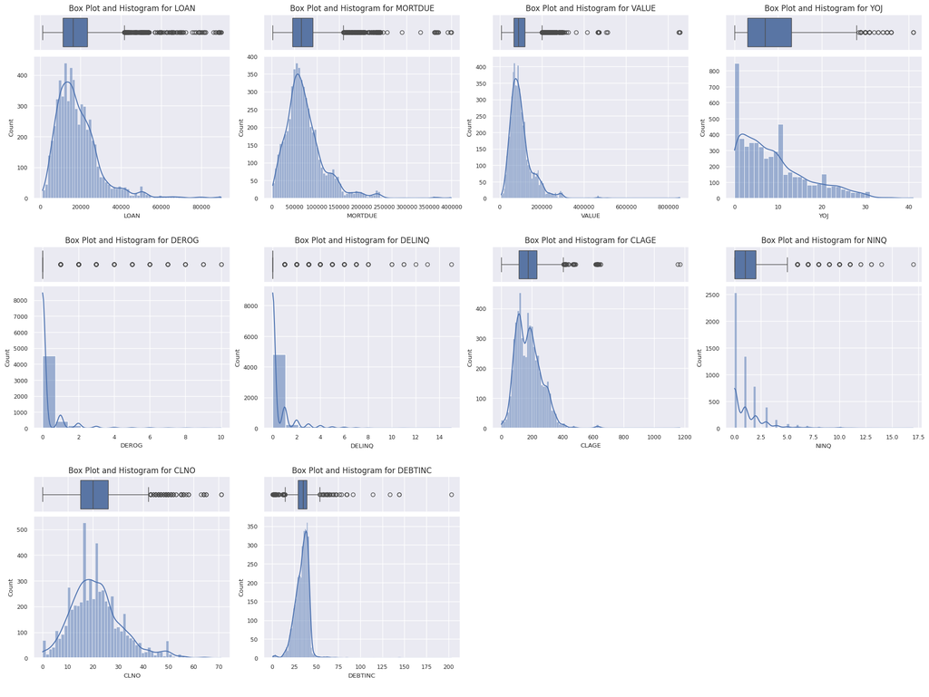

```python
# Boxplots and Histogram to under Numerical Features' Distribution
plot_numerical(df_hmeq,['BAD'])
```

**Observations:**

- **Distribution**:
  - **LOAN, MORTDUE, and VALUE**: These features might display **right-skewed distributions**, indicating a higher concentration of smaller values with a few large outliers.
  - **DEBTINC**: The distribution could also be skewed, with most applicants having a moderate debt-to-income ratio but a few with exceptionally high values.
- **Skewness**:
  - **LOAN**: If the histogram shows a long tail towards higher values, it suggests the feature is **positively skewed** (right-skewed), which could affect model assumptions, especially for linear models.
  - **DELINQ and DEROG**: These features may show **positive skewness**, as most applicants are likely to have few or no delinquencies or derogatory reports, with a few having high counts.
- **Outliers**:
  - **DEBTINC and LOAN**: Boxplots for these features are likely to show **outliers** with extreme values, especially for larger loans and high debt-to-income ratios. These outliers may need to be addressed through capping or transformation.
  - **DEROG, DELINQ, and NINQ**: A small number of applicants may have disproportionately high derogatory reports or credit inquiries, appearing as **outliers** on the boxplots.
  - **CLAGE**: While this may show a fairly normal distribution, there could still be **outliers** with very high credit ages, reflecting long-term credit users.

## Univariate Analysis - Categorical Values

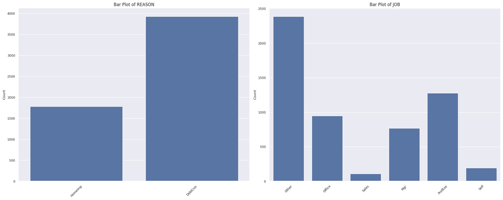

```python
# Display barplot for categorical values
plot_categorical_bars(df_hmeq)
```

**Observations:**

- **REASON**: The majority of applicants fall under the **DebtCon (Debt Consolidation)** category, with fewer applicants in the **HomeImp (Home Improvement)** category. This indicates that consolidating debt is a more common reason for applying for loans.
- **JOB**: The **Other** job category has the highest frequency, suggesting a diverse range of applicants whose occupations do not fit standard categories like **Manager** or **Office**. The distribution is skewed towards the **Other** category, with fewer applicants in more specific job types.
- **Skewness in Distribution**: Both **REASON** and **JOB** show an uneven distribution, with the top categories dominating. This might reflect biases in the dataset or the types of customers the bank tends to attract.

## Bivariate Analysis - Numerical Features vs Target Variable (BAD)

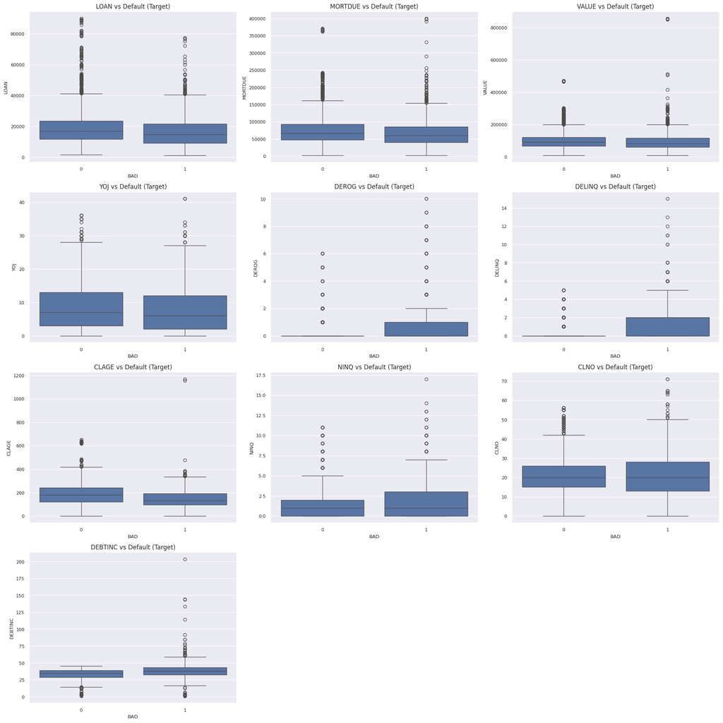

```python
# Draw Boxplots showing Predictor's relation with Target Variable (BAD)
plot_boxplots(df_hmeq.select_dtypes(include=['int64','float64']).drop('BAD', axis=1), df_hmeq['BAD'])
```

**Observations:**

## Bivariate Analysis - Categorical Features vs Target Variable (BAD)

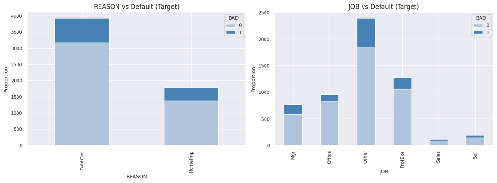

```python
# Display Stacked Barchart to show relation of Categorical Variables to Target Variable
plot_stacked_barcharts(df_hmeq.select_dtypes(include=['object']), df_hmeq['BAD'])
```

**Observations:**

## Multivariate Analysis - Correlation Heatmap

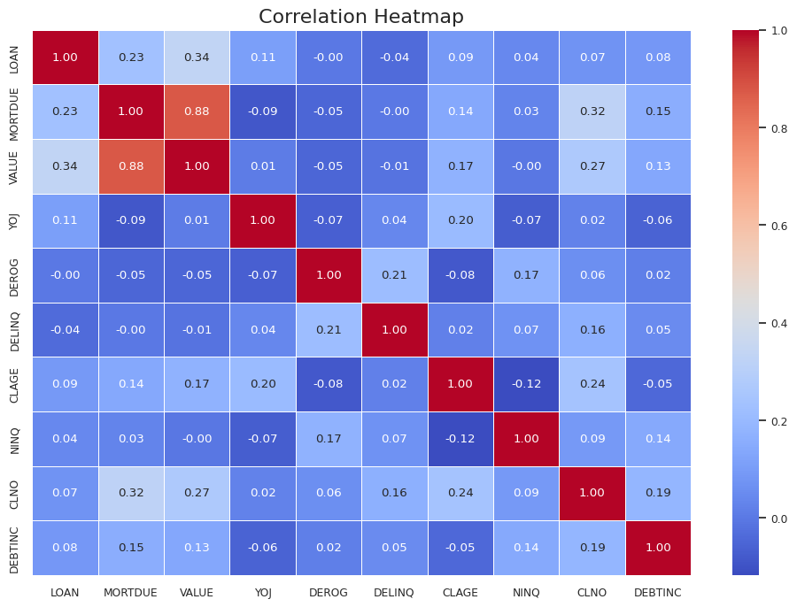

```python
# Identify correlation between numeric features using Correlation Heatmap
plot_correlation_heatmap(df_hmeq.drop(columns=['BAD']))
```

**Observations:**

## EDA Summary and Key Insights

The analysis highlighted significant patterns in both numerical and categorical features, offering a clearer understanding of loan default risk.

# Data Pre-Processing

- Missing Values Imputation
- Outlier Treatment
- Encode Categorical Columns
- Train-Validation-Test Split
- Multicollinearity Check (Linear models only)
- Scaling Dataset (Linear Models only)
- Data Pre-process Summary

## Functions to assist in Data Pre-processing

```python
# Imputes missing values for both training and testing datasets using KNN for numerical features and SimpleImputer (most frequent) for categorical features.
def impute_missing_values_knn(dataframe):
    """
    Parameters:
    - dataframe: DataFrame.

    Returns:
    - dataframe_imputed: Imputed data set (pandas DataFrame).
    """

    # Separate numerical and categorical columns in the training data
    numerical_cols = dataframe.select_dtypes(include=['float64', 'int64']).columns
    categorical_cols = dataframe.select_dtypes(include=['object']).columns

    # Imputation for numerical columns using KNN (fit on X_train, transform on both)
    knn_imputer = KNNImputer(n_neighbors=5)
    dataframe[numerical_cols] = knn_imputer.fit_transform(dataframe[numerical_cols])

    # Imputation for categorical columns using most frequent (fit on X_train, transform on both)
    cat_imputer = SimpleImputer(strategy='most_frequent')
    dataframe[categorical_cols] = cat_imputer.fit_transform(dataframe[categorical_cols])

    return dataframe

# Function to treat outliers for each column with outliers, excluding target column
def treat_outliers(df, exclude_columns):
    """
    Parameters:
    - df: pandas DataFrame
    - exclude_columns: list of columns to exclude from the outlier treatment.

    Returns:
    - DataFrame with outliers treated for the specified numerical columns.
    """
    # Exclude specified columns from outlier treatment
    numeric_cols = df.select_dtypes(include=['number']).columns.difference(exclude_columns)

    for column in numeric_cols:
        Q1 = df[column].quantile(0.25)
        Q3 = df[column].quantile(0.75)
        IQR = Q3 - Q1

        # Define the lower and upper bounds for outliers
        lower_bound = Q1 - 1.5 * IQR
        upper_bound = Q3 + 1.5 * IQR

        # Replace lower outliers with the lower bound and upper outliers with the upper bound
        df[column] = df[column].apply(lambda x: lower_bound if x < lower_bound else (upper_bound if x > upper_bound else x))

    return df

# Encodes categorical features in the DataFrame using one-hot encoding.
def encode_categorical(df):
    """
    Parameters:
    - df: DataFrame containing the features.

    Returns:
    - DataFrame with categorical features one-hot encoded.
    """
    # Select categorical columns
    categorical_cols = df.select_dtypes(include=['object']).columns

    # Apply one-hot encoding
    df_encoded = pd.get_dummies(df, columns=categorical_cols, drop_first=True)

    # Convert only boolean columns to integers (1/0)
    for col in df_encoded.columns:
        if df_encoded[col].dtype == 'bool':
            df_encoded[col] = df_encoded[col].astype(int)

    return df_encoded
```

## Missing Value Imputation

**Reasons for Choosing Imputation Methods**:

- **KNN Imputation (Numerical Data)**: Accounts for relationships between variables like loan amounts and debt-to-income ratios, leveraging patterns in similar rows.
- **Most Frequent Value (Categorical Data)**: Replaces missing values with the most common category, which is reasonable for features like **REASON** and **JOB**.

```python
# Calling function to impute missing values
df_hmeq_imputed = impute_missing_values_knn(df_hmeq)

# Check for missing values
print('Check Missing values dataset:\n')
display(df_hmeq_imputed.isna().sum())
```

```
Check Missing values dataset:
```

|  | 0 |
| --- | --- |
| BAD | 0 |
| LOAN | 0 |
| MORTDUE | 0 |
| VALUE | 0 |
| REASON | 0 |
| JOB | 0 |
| YOJ | 0 |
| DEROG | 0 |
| DELINQ | 0 |
| CLAGE | 0 |
| NINQ | 0 |
| CLNO | 0 |
| DEBTINC | 0 |

**dtype:** int64

**Conclusion:**

- Missing values have been corrected and now we will proceed to treat the outliers.

## Outlier Treatment

Outlier treatment is essential to prevent extreme values from distorting model performance, especially in financial data. The following code uses **IQR-based outlier treatment** to cap outliers within acceptable limits.

- No Outlier Treatment for **DEROG**, **DELINQ**, and **NINQ** due to their discrete nature.
- **Identifying Outliers**: The interquartile range (IQR) method calculates the range between the 25th and 75th percentiles, defining outliers as values outside this range.
- **Setting Bounds**: The lower and upper bounds are set at 1.5 times the IQR below Q1 and above Q3, respectively.
- **Capping Values**: Outliers below the lower bound are replaced by the lower bound, and those above the upper bound are capped at the upper limit.
- **Excluding Target Variable**: The target variable is excluded from outlier treatment to avoid impacting the response variable.

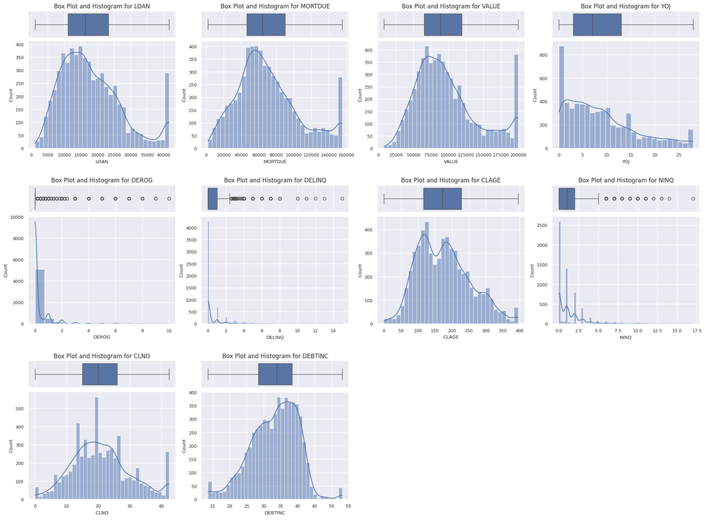

```python
# Treat outliers in Train Set
df_hmeq_imputed_ot = treat_outliers(df_hmeq_imputed, ['BAD','DEROG','DELINQ','NINQ'])

# Verify that Outliers are treated
plot_numerical(df_hmeq_imputed_ot,['BAD'])
```

**Observations:**

- Outliers for selected columns have been treated.

## Encoding Categorical Columns

We will encode the categorical columns and replace the output with 0s and 1s in preparation for model building.

- **One-hot Encoding:** One-Hot encoding will help us convert categorical values into binary representations.
- **No Clear Ordinal Values:** We chose to use One-Hot encoding for all categorical features as they do not demonstrate clear ordinal values, particularly in the JOB column, where no distinct hierarchy exists across roles.

```python
# Encode categorical columns using one-hot encoding
df_hmeq_final = encode_categorical(df_hmeq_imputed_ot)
display(df_hmeq_final.head())
```

|  | BAD | LOAN | MORTDUE | VALUE | YOJ | DEROG | DELINQ | CLAGE | NINQ | CLNO | DEBTINC | REASON_HomeImp | JOB_Office | JOB_Other | JOB_ProfExe | JOB_Sales | JOB_Self |
| --- | --- | --- | --- | --- | --- | --- | --- | --- | --- | --- | --- | --- | --- | --- | --- | --- | --- |
| 0 | 1.0 | 1100.0 | 25860.0 | 39025.0 | 10.5 | 0.0 | 0.0 | 94.366667 | 1.0 | 9.0 | 23.314070 | 1 | 0 | 1 | 0 | 0 | 0 |
| 1 | 1.0 | 1300.0 | 70053.0 | 68400.0 | 7.0 | 0.0 | 2.0 | 121.833333 | 0.0 | 14.0 | 40.532794 | 1 | 0 | 1 | 0 | 0 | 0 |
| 2 | 1.0 | 1500.0 | 13500.0 | 16700.0 | 4.0 | 0.0 | 0.0 | 149.466667 | 1.0 | 10.0 | 36.196050 | 1 | 0 | 1 | 0 | 0 | 0 |
| 3 | 1.0 | 1500.0 | 48080.6 | 56090.8 | 6.8 | 0.0 | 0.4 | 110.973073 | 0.4 | 10.8 | 29.512385 | 0 | 0 | 1 | 0 | 0 | 0 |
| 4 | 0.0 | 1700.0 | 97800.0 | 112000.0 | 3.0 | 0.0 | 0.0 | 93.333333 | 0.0 | 14.0 | 34.370509 | 1 | 1 | 0 | 0 | 0 | 0 |

## Train-Validation-Test Split

In this step, we split the dataset into training, validation, and testing sets to evaluate model performance more effectively.

- **Feature/Target Separation**: We segregated predictors (features) and the target variable to ensure the model is trained on relevant data.
- **Train/Validation/Test Split**: The dataset was split into training, validation, and test sets. The validation set helps us fine-tune models, while the test set evaluates performance on unseen data for accurate assessment.

This ensures the model is tested after proper tuning for better generalization.

```python
# Separate predictors and target variabl
X = df_hmeq_final.drop(columns=['BAD'])
y = df_hmeq_final['BAD']

print('Top 5 rows with predictors:\n')
display(X.head())
print('\nTop 5 rows with target variable:\n')
display(y.head())
```

```
Top 5 rows with predictors:
```

|  | LOAN | MORTDUE | VALUE | YOJ | DEROG | DELINQ | CLAGE | NINQ | CLNO | DEBTINC | REASON_HomeImp | JOB_Office | JOB_Other | JOB_ProfExe | JOB_Sales | JOB_Self |
| --- | --- | --- | --- | --- | --- | --- | --- | --- | --- | --- | --- | --- | --- | --- | --- | --- |
| 0 | 1100.0 | 25860.0 | 39025.0 | 10.5 | 0.0 | 0.0 | 94.366667 | 1.0 | 9.0 | 23.314070 | 1 | 0 | 1 | 0 | 0 | 0 |
| 1 | 1300.0 | 70053.0 | 68400.0 | 7.0 | 0.0 | 2.0 | 121.833333 | 0.0 | 14.0 | 40.532794 | 1 | 0 | 1 | 0 | 0 | 0 |
| 2 | 1500.0 | 13500.0 | 16700.0 | 4.0 | 0.0 | 0.0 | 149.466667 | 1.0 | 10.0 | 36.196050 | 1 | 0 | 1 | 0 | 0 | 0 |
| 3 | 1500.0 | 48080.6 | 56090.8 | 6.8 | 0.0 | 0.4 | 110.973073 | 0.4 | 10.8 | 29.512385 | 0 | 0 | 1 | 0 | 0 | 0 |
| 4 | 1700.0 | 97800.0 | 112000.0 | 3.0 | 0.0 | 0.0 | 93.333333 | 0.0 | 14.0 | 34.370509 | 1 | 1 | 0 | 0 | 0 | 0 |

```
Top 5 rows with target variable:
```

|  | BAD |
| --- | --- |
| 0 | 1.0 |
| 1 | 1.0 |
| 2 | 1.0 |
| 3 | 1.0 |
| 4 | 0.0 |

**dtype:** float64

```python
# Split full dataset into train and test sets
X_train_full, X_test, y_train_full, y_test = train_test_split(X, y, test_size=0.2, random_state=42, stratify=y)

print('Full Train and Test Sets:\n')
print(f'X_train_full shape: {X_train_full.shape}')
print(f'X_test shape: {X_test.shape}')
print(f'y_train_full shape: {y_train_full.shape}')
print(f'y_test shape: {y_test.shape}')

# Further split training set into train and validation sets
X_train, X_val, y_train, y_val = train_test_split(X_train_full, y_train_full, test_size=0.2, random_state=42, stratify=y_train_full)

print('\nTrain and Validation Sets:\n')
print(f'X_train shape: {X_train.shape}')
print(f'X_val shape: {X_val.shape}')
print(f'y_train shape: {y_train.shape}')
print(f'y_val shape: {y_val.shape}')
```

```
Full Train and Test Sets:

X_train_full shape: (4768, 16)
X_test shape: (1192, 16)
y_train_full shape: (4768,)
y_test shape: (1192,)

Train and Validation Sets:

X_train shape: (3814, 16)
X_val shape: (954, 16)
y_train shape: (3814,)
y_val shape: (954,)
```

## Multicollinearity Check (Linear models only)

We will be using linear models like **Logistic Regression** and **Linear Discriminant Analysis**, it is crucial to check for multicollinearity among the features and address it if necessary.

```python
vif_result = calculate_vif(X_train)
display(vif_result.sort_values(by='VIF', ascending=False))
```

|  | Feature | VIF |
| --- | --- | --- |
| 2 | VALUE | 3.469266 |
| 1 | MORTDUE | 3.203948 |
| 12 | JOB_Other | 2.622552 |
| 13 | JOB_ProfExe | 2.219166 |
| 11 | JOB_Office | 1.916907 |
| 8 | CLNO | 1.302018 |
| 15 | JOB_Self | 1.270643 |
| 0 | LOAN | 1.256190 |
| 6 | CLAGE | 1.158137 |
| 14 | JOB_Sales | 1.152413 |
| 10 | REASON_HomeImp | 1.114662 |
| 9 | DEBTINC | 1.112177 |
| 4 | DEROG | 1.098687 |
| 5 | DELINQ | 1.092507 |
| 3 | YOJ | 1.086987 |
| 7 | NINQ | 1.083350 |

**Observations:**

- **No Immediate Concern:** While VALUE and MORTDUE have relatively higher VIF values, they are still below the common threshold of 5, meaning they do not present a severe multicollinearity problem.

## Dataset Scaling using StandardScaler (Linear models only)

Scaling is essential for models that are sensitive to the magnitude of features, such as **Logistic Regression** and **Linear Discriminant Analysis**. These models can be influenced by features with larger values, leading to biased model performance.

```python
# Scale the predictor variables
scaler = StandardScaler()
X_train_scaled = X_train.copy()
X_val_scaled = X_val.copy()
X_test_scaled = X_test.copy()

# Fit the scaler on X_train and transform X_train
X_train_scaled[X_train_scaled.columns] = scaler.fit_transform(X_train[X_train_scaled.columns])

# Apply the same scaler to X_test and X_val datasets
X_test_scaled[X_test_scaled.columns] = scaler.transform(X_test[X_test_scaled.columns])
X_val_scaled[X_val_scaled.columns] = scaler.transform(X_val[X_val_scaled.columns])

print('Scaled Training Dataset:')
display(X_train_scaled.head())
print('\nScaled Validation Dataset:')
display(X_val_scaled.head())
print('\nScaled Test Dataset:')
display(X_test_scaled.head())
```

```
Scaled Training Dataset:
```

|  | LOAN | MORTDUE | VALUE | YOJ | DEROG | DELINQ | CLAGE | NINQ | CLNO | DEBTINC | REASON_HomeImp | JOB_Office | JOB_Other | JOB_ProfExe | JOB_Sales | JOB_Self |
| --- | --- | --- | --- | --- | --- | --- | --- | --- | --- | --- | --- | --- | --- | --- | --- | --- |
| 2219 | -0.451656 | 0.109675 | -0.113334 | -0.262479 | -0.344 | 2.149522 | 0.044098 | -0.701124 | 1.286339 | 0.895970 | -0.651304 | -0.424782 | 1.087162 | -0.520897 | -0.140663 | -0.176322 |
| 2715 | -0.266884 | -1.043493 | -0.626532 | -0.262479 | -0.344 | -0.460507 | 0.997462 | -0.097547 | -0.534220 | -1.435184 | -0.651304 | -0.424782 | -0.919826 | 1.919767 | -0.140663 | -0.176322 |
| 5213 | 1.124338 | 1.088158 | 2.301961 | 1.926992 | -0.344 | -0.460507 | 0.026690 | -0.701124 | -0.320037 | -1.383765 | -0.651304 | -0.424782 | 1.087162 | -0.520897 | -0.140663 | -0.176322 |
| 2189 | -0.462525 | -0.151388 | -0.293733 | 0.695414 | -0.344 | -0.460507 | -0.795508 | -0.701124 | 0.322514 | 0.542311 | -0.651304 | 2.354150 | -0.919826 | -0.520897 | -0.140663 | -0.176322 |
| 1951 | -0.549476 | -0.109665 | -0.113424 | 2.474360 | -0.344 | -0.460507 | -0.103279 | -0.097547 | -0.748404 | 1.182170 | 1.535381 | 2.354150 | -0.919826 | -0.520897 | -0.140663 | -0.176322 |

```
Scaled Validation Dataset:
```

|  | LOAN | MORTDUE | VALUE | YOJ | DEROG | DELINQ | CLAGE | NINQ | CLNO | DEBTINC | REASON_HomeImp | JOB_Office | JOB_Other | JOB_ProfExe | JOB_Sales | JOB_Self |
| --- | --- | --- | --- | --- | --- | --- | --- | --- | --- | --- | --- | --- | --- | --- | --- | --- |
| 2277 | -0.429918 | 2.378587 | 1.833635 | -0.262479 | 0.402028 | 0.409502 | 0.186317 | 1.713183 | 0.536697 | 1.174072 | -0.651304 | -0.424782 | -0.919826 | 1.919767 | -0.140663 | -0.176322 |
| 4696 | 0.754795 | 1.085365 | 0.967168 | 0.284888 | 2.142760 | -0.460507 | 0.075776 | 2.316759 | -0.320037 | 1.090548 | -0.651304 | -0.424782 | -0.919826 | -0.520897 | -0.140663 | -0.176322 |
| 5830 | 2.580775 | -0.657679 | 0.108434 | 0.011205 | -0.344000 | -0.460507 | 0.424952 | 1.109606 | 1.500523 | 0.809520 | 1.535381 | -0.424782 | -0.919826 | -0.520897 | -0.140663 | 5.671439 |
| 5917 | 2.580775 | -0.161889 | 1.034485 | 0.011205 | -0.344000 | -0.460507 | -0.812552 | -0.701124 | -1.069679 | 0.976144 | 1.535381 | 2.354150 | -0.919826 | -0.520897 | -0.140663 | -0.176322 |
| 3960 | 0.309169 | -0.011445 | 0.074437 | -0.809847 | -0.344000 | -0.460507 | 0.456668 | -0.097547 | -0.855496 | -0.038787 | 1.535381 | -0.424782 | 1.087162 | -0.520897 | -0.140663 | -0.176322 |

```
Scaled Test Dataset:
```

|  | LOAN | MORTDUE | VALUE | YOJ | DEROG | DELINQ | CLAGE | NINQ | CLNO | DEBTINC | REASON_HomeImp | JOB_Office | JOB_Other | JOB_ProfExe | JOB_Sales | JOB_Self |
| --- | --- | --- | --- | --- | --- | --- | --- | --- | --- | --- | --- | --- | --- | --- | --- | --- |
| 4798 | 0.787402 | -0.807257 | -0.588342 | 1.379624 | -0.344 | -0.460507 | 0.073691 | -0.097547 | 0.108330 | 0.077116 | -0.651304 | 2.354150 | -0.919826 | -0.520897 | -0.140663 | -0.176322 |
| 3716 | 0.189611 | -1.031512 | -0.803256 | 0.695414 | -0.344 | -0.460507 | -0.742711 | -0.097547 | -0.427129 | 0.678666 | -0.651304 | -0.424782 | 1.087162 | -0.520897 | -0.140663 | -0.176322 |
| 1472 | -0.745117 | -0.435072 | -0.715762 | -0.536163 | -0.344 | -0.460507 | 1.849583 | -0.701124 | -1.176771 | 0.023678 | -0.651304 | -0.424782 | 1.087162 | -0.520897 | -0.140663 | -0.176322 |
| 1050 | -0.897282 | -0.697615 | -0.841311 | -0.946689 | -0.344 | 0.409502 | -1.205974 | -0.701124 | -0.212945 | 0.776482 | -0.651304 | -0.424782 | 1.087162 | -0.520897 | -0.140663 | -0.176322 |
| 87 | -1.505942 | -0.341265 | -0.631559 | -0.741426 | -0.344 | 0.409502 | -0.116732 | -0.701124 | -0.320037 | -0.219303 | 1.535381 | -0.424782 | 1.087162 | -0.520897 | -0.140663 | -0.176322 |

**Observations:**

- After scaling the train and test datasets using StandardScaler, these datasets will be used in building Linear Models.

## Resample Dataset using Synthetic Minority Oversampling Technique

```python
# Handle Imbalanced Dataset
sm = SMOTE(random_state=42)
X_train_resampled, y_train_resampled = sm.fit_resample(X_train, y_train)
X_train_scaled_resampled, y_train_scaled_resampled = sm.fit_resample(X_train_scaled, y_train)

# Check the distribution of the target variable
print(y_train_resampled.value_counts(normalize=True)*100)
print(y_train_scaled_resampled.value_counts(normalize=True)*100)
```

```
BAD
1.0    50.0
0.0    50.0
Name: proportion, dtype: float64
BAD
1.0    50.0
0.0    50.0
Name: proportion, dtype: float64
```

## Data Pre-processing Summary

**Observations on Data Preprocessing Steps:**

- **Missing Value Treatment**: Imputed missing values using appropriate techniques for both numerical and categorical variables to ensure a complete dataset.
- **Outlier Treatment**: Handled outliers based on interquartile range (IQR) to reduce their impact on model performance.
- **Encoding using OneHotEncoding**: Successfully transformed categorical variables into binary columns, ensuring no multicollinearity by dropping the first category.
- **Train-Test Split**: Split the dataset into training and test sets to ensure model evaluation on unseen data.
- **Multicollinearity Check (for Linear Models)**: Checked for multicollinearity using Variance Inflation Factor (VIF), found no significant multicollinearity, and skipped further treatment.
- **Dataset Scaling (for Linear Models)**: Applied StandardScaler to ensure all numerical features are on the same scale, critical for models sensitive to feature magnitudes.
- **Treated Imbalance Datasets**: Target variable shows only 19% observations with BAD = 1 (Defaults). Applied Synthetic Minority Oversampling Technique (SMOTE) to balance the skewed data.

**Next Step:** You are now ready to proceed with **model building** using the preprocessed data. Start by training linear models such as **Logistic Regression** and **Linear Discriminant Analysis**, followed by other suitable algorithms.

# Model Building Approach and Evaluation Criteria

- Model Building Approach
- Evaluating Model Performance

### Model Building Approach

In this phase, we will focus on building both linear and ensemble models to predict loan defaults, utilizing the preprocessed data. Here's the detailed approach:

**Linear Models (on Scaled Datasets)**:

**Ensemble Methods**:

- **Random Forest**: We'll first build a basic Random Forest model, followed by hyperparameter tuning to optimize performance using techniques like grid search or random search.
- **ADA Boost**: We will build an Adaptive Boosting (ADA Boost) model and fine-tune its parameters to improve model performance.
- **Gradient Boosting**: This model will be trained and then optimized through hyperparameter tuning to enhance its ability to handle complex decision boundaries.
- **XGBoost**: We'll start with the default XGBoost model and tune its hyperparameters to improve its predictive power and speed.

**Benefits of this Approach:**

- **Linear Models**: These provide easy interpretability and are useful for understanding the importance of features, especially after removing insignificant variables.
- **Ensemble Methods**: These models are more flexible, can handle feature interactions better, and are less prone to overfitting due to techniques like bagging and boosting. Hyperparameter tuning will further enhance their performance.

### Evaluating Model Performance

**Performance Metric Check and Model Selection:**

- After training all models, we will evaluate them using performance metrics such as **accuracy, precision, recall, F1-score**, and **AUC-ROC** to determine the best-performing model. We will compare the results, focusing on both predictive accuracy and the model's ability to generalize. The model with the best balance between performance and interpretability will be selected as the final model.
- We will also attempt to estimate how much each model contributes in terms of savings through accurately predicting defaulters contributing to overal profits for the banks. We use following assumption when calculating potential profits.

**Assumptions:**

**Profit Calculation:**

# Model Building

**Linear Models**

- Logistic Regression (LR) Models
- Linear Discriminant Analysis (LDA) Models

**Ensemble Technique Models**

- Randome Forest Models
- ADA Boost Models
- Gradient Boosting Models
- XGBoost Models

## Functions to assist in Model Building and Performance Evaluation

```python
def model_performance_classification(model, predictors, target, modelname, X_train=X, y_train=y, threshold=0.5):
    """
    model: classifier (from sklearn)
    predictors: independent variables
    target: dependent variable
    modelname: name of the model, which will be used as the index in the DataFrame
    X_train: Training data (predictors), used to calculate profit
    y_train: Training target variable (BAD), used to calculate profit
    threshold: threshold for classifying the observation as class 1
    """
    # Get predicted probabilities for class 1
    pred_prob = model.predict_proba(predictors)[:, 1]

    # Apply the threshold to get binary predictions
    pred = (pred_prob >= threshold).astype(int)

    # Calculate performance metrics
    acc = accuracy_score(target, pred)  # Accuracy
    recall = recall_score(target, pred)  # Recall
    precision = precision_score(target, pred)  # Precision
    f1 = f1_score(target, pred)  # F1-score
    roc = roc_auc_score(target, pred_prob)  # ROC-AUC using predicted probabilities

    # Calculate confusion matrix
    tn, fp, fn, tp = confusion_matrix(target, pred).ravel()

    # Profit calculation logic (customized based on previous profit calculation)
    # Calculate average loan amounts based on actual y_train data
    tp_profit = X_train.loc[y_train == 1, 'LOAN'].mean()  # Average loan for defaulted loans
    avg_non_defaulted_loan = X_train.loc[y_train == 0, 'LOAN'].mean()  # Average loan for non-defaulted loans
    avg_loan_value = X_train['LOAN'].mean()  # Average loan value for all loans

    # Calculate FP cost (2% per annum for 10 years for average non-defaulted loan)
    fp_cost = avg_non_defaulted_loan * (1 + 0.02) ** 10 - avg_non_defaulted_loan

    # Calculate FN cost (average loan value + 3% operating cost for 5 years)
    fn_cost = avg_loan_value + (avg_loan_value * 0.03 * 5)

    # Set TN profit to 0 (neutral outcome)
    tn_profit = 0

    # Calculate total profit based on confusion matrix and estimated losses
    total_profit = (tp * tp_profit) - (fp * fp_cost) - (fn * fn_cost) - (tn * tn_profit)

    # Format the profit value in currency format (e.g., $30,000)
    formatted_profit = locale.currency(total_profit, grouping=True)

    # Creating a dataframe of metrics with modelname as the index, including profit
    df_perf = pd.DataFrame(
        {
            "Accuracy": [acc],
            "Recall": [recall],
            "Precision": [precision],
            "F1": [f1],
            "ROC_AUC": [roc],
            "Profit": [formatted_profit] #,  # Adding profit to the performance metrics
            # "tn": [tn],
            # "fp": [fp],
            # "fn": [fn],
            # "tp": [tp],
            # "tn_profit": [tn_profit],
            # "tp_profit": [tp_profit],
            # "avg_non_defaulted_loan": [avg_non_defaulted_loan],
            # "avg_loan_value": [avg_loan_value],
            # "FP_Cost": [fp_cost],
            # "FN_Cost": [fn_cost]
        },
        index=[modelname]
    )

    return df_perf

# Provided function to plot confusion matrix
def confusion_matrix_plot(model, predictors, target, threshold=0.5):
    """
    model: classifier (from sklearn)
    predictors: independent variables
    target: dependent variable
    threshold: threshold for classifying the observation as class 1
    """
    # Get predicted probabilities for class 1
    y_pred_prob = model.predict_proba(predictors)[:, 1]

    # Apply the threshold to get binary predictions
    y_pred = (y_pred_prob >= threshold).astype(int)

    # Generate confusion matrix
    cm = confusion_matrix(target, y_pred)

    # Generate labels for each cell with counts and percentages
    labels = np.asarray(
        [
            ["{0:0.0f}".format(item) + "\n{0:.2%}".format(item / cm.sum())]
            for item in cm.flatten()
        ]
    ).reshape(2, 2)

    # Plot confusion matrix
    plt.figure(figsize=(6, 4))
    sns.heatmap(cm, annot=labels, fmt="", cmap="Blues", cbar=False)
    plt.ylabel("True label")
    plt.xlabel("Predicted label")
    plt.title(f"Confusion Matrix (Threshold = {threshold})")
    plt.show()

def find_optimum_cutoff(model, predictors, targets):
    """
    Find the optimal threshold for a given model and dataset based on Recall Score.

    Parameters:
    - model: Trained model (logistic regression, random forest, etc.)
    - predictors: Independent variables (X_test, X_train, etc.)
    - targets: True values for the dependent variable (y_test, y_train, etc.)

    Returns:
    - best_threshold: The threshold with the highest Recall Score
    - results_df: A DataFrame containing the performance metrics for different thresholds
    """
    # Generate predicted probabilities from the model
    y_prob_pred = model.predict(predictors)

    # Define threshold values to test
    thresholds = np.arange(0.1, 0.9, 0.01)

    # List to store performance results
    results = []

    for threshold in thresholds:
        # Convert probabilities to binary predictions based on the threshold
        y_pred = (y_prob_pred >= threshold).astype(int)

        # Calculate performance metrics
        accuracy = accuracy_score(targets, y_pred)
        precision = precision_score(targets, y_pred)
        recall = recall_score(targets, y_pred)
        f1 = f1_score(targets, y_pred)
        roc_auc = roc_auc_score(targets, y_prob_pred)

        # Store results for each threshold
        results.append({
            'Threshold': threshold,
            'Accuracy': accuracy,
            'Precision': precision,
            'Recall': recall,
            'F1 Score': f1,
            'ROC-AUC': roc_auc
        })

    # Convert results to a DataFrame for analysis
    results_df = pd.DataFrame(results)

    # Find the best threshold based on the highest Recall Score
    best_threshold = results_df.loc[results_df['Recall'].idxmax()]

    return best_threshold

def profit_score(y_true, y_pred, X_train, y_train):
    """
    Custom profit-based scoring function using the proposed TP, FP, FN, and TN calculations.

    Parameters:
    - y_true: True labels (BAD)
    - y_pred: Predicted labels
    - X_train: The full training dataset (predictors, including 'LOAN')
    - y_train: The target dataset (actual BAD values)

    Returns:
    - profit: Total profit/loss based on classification outcomes and estimated loss
    """
    # Calculate average loan amounts for TP, FP, and FN based on y_train (actual defaults)
    tp_profit = X_train.loc[y_train == 1, 'LOAN'].mean()  # Average loan for defaulted loans
    avg_non_defaulted_loan = X_train.loc[y_train == 0, 'LOAN'].mean()  # Average loan for non-defaulted loans
    avg_loan_value = X_train['LOAN'].mean()  # Average loan value for all loans

    # Calculate FP cost (2% per annum for 10 years for average non-defaulted loan)
    fp_cost = avg_non_defaulted_loan * (1 + 0.02) ** 10 - avg_non_defaulted_loan

    # Calculate FN cost (average loan value + 3% operating cost for 5 years)
    fn_cost = avg_loan_value + (avg_loan_value * 0.03 * 5)

    # Set TN profit to 0 (neutral outcome)
    tn_profit = 0

    # Compute confusion matrix
    tn, fp, fn, tp = confusion_matrix(y_true, y_pred).ravel()

    # Calculate total profit/loss based on confusion matrix and estimated losses
    total_profit = (tp * tp_profit) + (fp * fp_cost) + (fn * fn_cost) + (tn * tn_profit)

    return total_profit

# Tune hyperparameters of models using GridSearchCV.
def tune_model(model, X_train, y_train, param_grid=None, cv=5, scoring='recall'):
    """
    Parameters:
    - model: The machine learning model to tune (e.g., LogisticRegression, RandomForest, etc.)
    - X_train: Training features
    - y_train: Training labels
    - param_grid: Dictionary of hyperparameters to search. If None, a default grid is used.
    - cv: Number of cross-validation folds (default is 5)
    - scoring: Metric to optimize (default is 'recall')

    Returns:
    - best_estimator: The model with the best hyperparameters
    """
    # Type of scoring used to compare parameter combinations
    scorer = metrics.make_scorer(metrics.recall_score)

    # Initialize GridSearchCV
    grid_search = GridSearchCV(model, param_grid, cv=cv, scoring=scorer)

    # Fit the GridSearchCV with training data
    grid_search.fit(X_train, y_train)

    # Get best estimator and best CV score
    best_estimator = grid_search.best_estimator_
    best_cv_score = grid_search.best_score_

    # Return the best estimator
    return best_estimator, best_cv_score

# Create a custom scorer using make_scorer
custom_profit_scorer = make_scorer(
    profit_score,
    greater_is_better=True,
    X_train=X_train,  # Pass the predictors
    y_train=y_train   # Pass the target variable
)
```

## Logistic Regression Models

We will develop several Logistic Regression models to determine the best performers based on Recall scores and assess their ability to generalize effectively on unseen data.

- Model on Scaled Data
- Model on Scaled Data using Hyper Parameter Tuning
- Model performance comparison and Summary

### Logistic Regression on Scaled Data

```
Logistic Regression Performance:
```

|  | Accuracy | Recall | Precision | F1 | ROC_AUC | Profit |
| --- | --- | --- | --- | --- | --- | --- |
| Logistic Regression Scaled (Train) | 0.649712 | 0.802891 | 0.340011 | 0.477717 | 0.793413 | $2,162,385.43 |
| Logistic Regression Scaled (Validation) | 0.628931 | 0.763158 | 0.319383 | 0.450311 | 0.765259 | $206,718.05 |

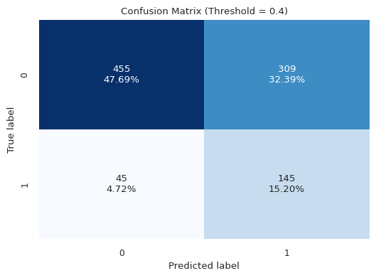

```python
# Initialize and train the logistic regression model
logistic_model_scaled = LogisticRegression(solver='liblinear', random_state=42, class_weight='balanced')
logistic_model_scaled.fit(X_train_scaled, y_train)

# Evaluate model performance
lr_scaled_train_perf = model_performance_classification(logistic_model_scaled, X_train_scaled, y_train, "Logistic Regression Scaled (Train)", threshold=0.40)
lr_scaled_val_perf = model_performance_classification(logistic_model_scaled, X_val_scaled, y_val, "Logistic Regression Scaled (Validation)", threshold=0.40)

# Display Performance Metrics
print("Logistic Regression Performance:")
lr_scaled_perf = pd.concat([lr_scaled_train_perf, lr_scaled_val_perf])
display(lr_scaled_perf)

# Plot the confusion matrix for the validation set
confusion_matrix_plot(logistic_model_scaled, X_val_scaled, y_val, threshold=0.40)
```

### Tuned Logistic Regression Model

[output not shown]

|  | Accuracy | Recall | Precision | F1 | ROC_AUC | Profit |
| --- | --- | --- | --- | --- | --- | --- |
| Logistic Regression Tuned on Scaled Data (Train) | 0.647614 | 0.806833 | 0.339039 | 0.477449 | 0.793416 | $2,229,660.90 |
| Logistic Regression Tuned on Scaled Data (Validation) | 0.627883 | 0.763158 | 0.318681 | 0.449612 | 0.765342 | $202,678.79 |

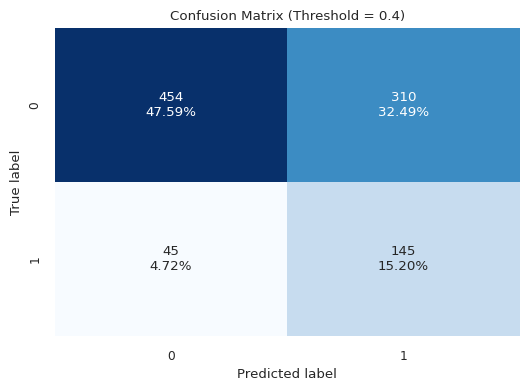

```python
# Define Parameter Grid
param_grid = {
    'C': np.arange(0.1, 1.1, 0.01)
}

# Tune Logistic Regression Model
best_lr_model, best_lr_cv_score = tune_model(logistic_model_scaled, X_train_scaled, y_train, param_grid=param_grid, cv=5)
print(f'Best CV Score: {best_lr_cv_score}')
print(f'\nBest Parameters: {best_lr_model.get_params()}')

# Evaluate Performance of the Model
lr_scaled_tuned_train_perf = model_performance_classification(best_lr_model, X_train_scaled, y_train, "Logistic Regression Tuned on Scaled Data (Train)", threshold=0.40)
lr_scaled_tuned_val_perf = model_performance_classification(best_lr_model, X_val_scaled, y_val, "Logistic Regression Tuned  on Scaled Data (Validation)", threshold=0.40)

# Display Performance Metrics
print("Tuned Logistic Regression Performance:")
lr_scaled_tuned_perf = pd.concat([lr_scaled_tuned_train_perf, lr_scaled_tuned_val_perf])
display(lr_scaled_tuned_perf)

# Plot the confusion matrix for the validation set
confusion_matrix_plot(best_lr_model, X_val_scaled, y_val, threshold=0.40)
```

### Logistic Model Comparison and Summary

```python
# Combine and Compare Logstic Model Performance
lr_perf = pd.concat([lr_scaled_perf, lr_scaled_tuned_perf])
display(lr_perf)
```

|  | Accuracy | Recall | Precision | F1 | ROC_AUC | Profit |
| --- | --- | --- | --- | --- | --- | --- |
| Logistic Regression Scaled (Train) | 0.649712 | 0.802891 | 0.340011 | 0.477717 | 0.793413 | $2,162,385.43 |
| Logistic Regression Scaled (Validation) | 0.628931 | 0.763158 | 0.319383 | 0.450311 | 0.765259 | $206,718.05 |
| Logistic Regression Tuned on Scaled Data (Train) | 0.647614 | 0.806833 | 0.339039 | 0.477449 | 0.793416 | $2,229,660.90 |
| Logistic Regression Tuned on Scaled Data (Validation) | 0.627883 | 0.763158 | 0.318681 | 0.449612 | 0.765342 | $202,678.79 |

**Observations:**

- Both models, **Logistic Regression Scaled** and **Tuned on Scaled Data**, demonstrate strong **Recall** on both training and validation sets. Recall values (80.29% on training, 76.32% on validation) show that these models are effective at identifying defaulters, which is important for minimizing missed defaulters (**False Negatives**).
- The **Precision** is relatively low across both models (around 34% on training and 32% on validation), meaning a significant number of non-defaulters are being classified as defaulters (**False Positives**). This highlights a trade-off: while the models capture most defaulters, many predictions of defaulters may be incorrect.
- In terms of **Profit**, the tuned model slightly outperforms the scaled version on the training set (\$2,229,660.90 vs. \$2,162,385.43). However, on the validation set, the profit difference is minimal (\$202,678.79 vs. $206,718.05), indicating that tuning did not substantially improve the validation performance.
- **Recommendation**: Given the similar performance, the **Logistic Regression Scaled** model performed slightly better in terms of **validation profit** and overall consistency, making it the better choice between the two.

**Next Step:**

We will now evaluate **Random Forest models** to compare their performance with Logistic Regression, focusing on improving **Recall**, **Precision**, and **Profit** to find the best-performing model.

## Linear Discriminant Analysis (LDA) Models

We will also develop several LDA models to evaluate their performance based on Recall scores and determine how well they generalize to unseen data.

- Model on Original (Scaled) Data
- Model on Oversampled Data (SMOTE)
- Model on Original (Scaled) Data with Hyperparameter Tuning
- Model on Oversampled Data with Hyperparameter Tuning

### LDA Model on Original Data

```
LDA Performance:
```

|  | Accuracy | Recall | Precision | F1 | ROC_AUC | Profit |
| --- | --- | --- | --- | --- | --- | --- |
| LDA - Original (Train) | 0.819874 | 0.369251 | 0.57582 | 0.449960 | 0.793195 | -$6,170,986.31 |
| LDA - Original (Validation) | 0.806080 | 0.342105 | 0.52000 | 0.412698 | 0.765583 | -$1,766,368.52 |

```
Confusion Matrix:
```

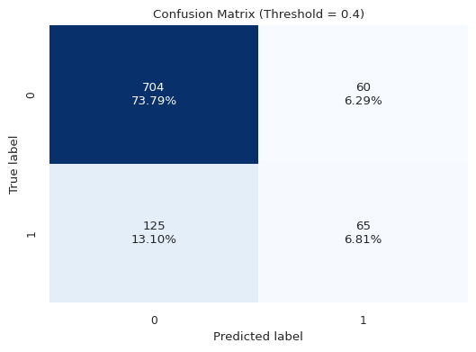

```python
# Initialize LDA
lda = LinearDiscriminantAnalysis()

# Train the LDA model
lda.fit(X_train_scaled, y_train)

# Evaluate Model Performance
lda_train_perf = model_performance_classification(lda, X_train_scaled, y_train, 'LDA - Original (Train)', threshold=0.4)
lda_val_perf = model_performance_classification(lda, X_val_scaled, y_val, 'LDA - Original (Validation)', threshold=0.4)

# Display Performance Metrics
print("LDA Performance:")
lda_org_perf = pd.concat([lda_train_perf, lda_val_perf])
display(lda_org_perf)

# Plot Confusion Matrix
print("Confusion Matrix:")
confusion_matrix_plot(lda, X_val_scaled, y_val, threshold=0.4)
```

### LDA Model on Oversampled Data (SMOTE)

```
LDA Performance:
```

|  | Accuracy | Recall | Precision | F1 | ROC_AUC | Profit |
| --- | --- | --- | --- | --- | --- | --- |
| LDA - Oversampled (Train) | 0.708156 | 0.804455 | 0.674540 | 0.733791 | 0.792568 | $23,285,278.60 |
| LDA - Oversampled (Validation) | 0.633124 | 0.763158 | 0.322222 | 0.453125 | 0.758983 | $222,875.12 |

```
Confusion Matrix:
```

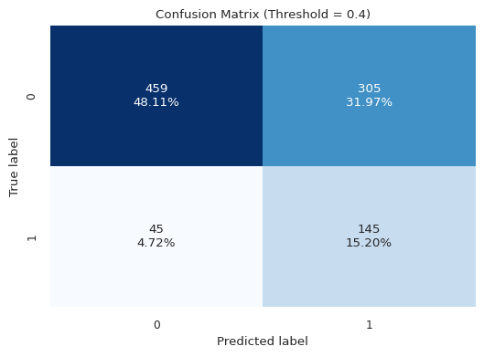

```python
# Initialize LDA Model
lda_resampled = LinearDiscriminantAnalysis()

# Train the LDA model
lda_resampled.fit(X_train_scaled_resampled, y_train_scaled_resampled)

# Evaluate Model Performance
lda_resampled_train_perf = model_performance_classification(lda_resampled, X_train_scaled_resampled, y_train_scaled_resampled, 'LDA - Oversampled (Train)', threshold=0.4)
lda_resampled_val_perf = model_performance_classification(lda_resampled, X_val_scaled, y_val, 'LDA - Oversampled (Validation)', threshold=0.4)

# Display Performance Metrics
print("LDA Performance:")
lda_resampled_perf = pd.concat([lda_resampled_train_perf, lda_resampled_val_perf])
display(lda_resampled_perf)

# Plot Confusion Matrix
print("Confusion Matrix:")
confusion_matrix_plot(lda_resampled, X_val_scaled, y_val, threshold=0.4)
```

### LDA Model Tuned on Original Data

```
Best CV Score: 0.31016511867905056

Best Parameters: {'covariance_estimator': None, 'n_components': None, 'priors': None, 'shrinkage': 0.9, 'solver': 'lsqr', 'store_covariance': False, 'tol': 0.0001}
LDA Performance:
```

|  | Accuracy | Recall | Precision | F1 | ROC_AUC | Profit |
| --- | --- | --- | --- | --- | --- | --- |
| LDA - Tuned (Train) | 0.814106 | 0.400788 | 0.546595 | 0.462472 | 0.787358 | -$5,463,133.43 |
| LDA - Tuned (Validation) | 0.805031 | 0.368421 | 0.514706 | 0.429448 | 0.766540 | -$1,604,425.13 |

```
Confusion Matrix:
```

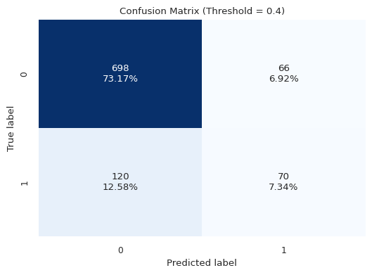

```python
# Define parameter grid
lda_param_grid = {
    'solver': ['svd', 'lsqr', 'eigen'],
    'shrinkage': [None, 'auto', 0.1, 0.5, 0.9]  # Only for 'lsqr' and 'eigen'
}

# Initialize LDA Model
tuned_lda = LinearDiscriminantAnalysis()

# Tune Model using GridSearchCV()
best_lda_model, best_lda_cv = tune_model(tuned_lda, X_train_scaled, y_train, param_grid=lda_param_grid, cv=5)
print(f'Best CV Score: {best_lda_cv}')
print(f'\nBest Parameters: {best_lda_model.get_params()}')

# Evaluate Model Performance
lda_tuned_train_perf = model_performance_classification(best_lda_model, X_train_scaled, y_train, 'LDA - Tuned (Train)', threshold=0.4)
lda_tuned_val_perf = model_performance_classification(best_lda_model, X_val_scaled, y_val, 'LDA - Tuned (Validation)', threshold=0.4)

# Display Performance Metrics
print("LDA Performance:")
lda_tuned_perf = pd.concat([lda_tuned_train_perf, lda_tuned_val_perf])
display(lda_tuned_perf)

# Plot Confusion Matrix
print("Confusion Matrix:")
confusion_matrix_plot(best_lda_model, X_val_scaled, y_val, threshold=0.4)
```

### LDA Model Tuned on Oversampled Data

```
Best CV Score: 0.6718064983499236

Best Parameters: {'covariance_estimator': None, 'n_components': None, 'priors': None, 'shrinkage': None, 'solver': 'svd', 'store_covariance': False, 'tol': 0.0001}
LDA Performance:
```

|  | Accuracy | Recall | Precision | F1 | ROC_AUC | Profit |
| --- | --- | --- | --- | --- | --- | --- |
| LDA - Oversampled Tuned (Train) | 0.708156 | 0.804455 | 0.674540 | 0.733791 | 0.792568 | $23,285,278.60 |
| LDA - Oversampled Tuned (Validation) | 0.633124 | 0.763158 | 0.322222 | 0.453125 | 0.758983 | $222,875.12 |

```
Confusion Matrix:
```

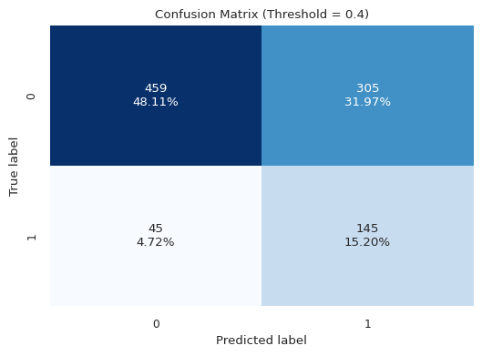

```python
# Tune LDA Model using GridSearchCV()
best_lda_resampled_model, best_lda_resampled_cv = tune_model(tuned_lda, X_train_scaled_resampled, y_train_scaled_resampled, param_grid=lda_param_grid, cv=5)
print(f'Best CV Score: {best_lda_resampled_cv}')
print(f'\nBest Parameters: {best_lda_resampled_model.get_params()}')

# Evaluate Performance of Model
lda_resampled_tuned_train_perf = model_performance_classification(best_lda_resampled_model, X_train_scaled_resampled, y_train_scaled_resampled, 'LDA - Oversampled Tuned (Train)', threshold=0.4)
lda_resampled_tuned_val_perf = model_performance_classification(best_lda_resampled_model, X_val_scaled, y_val, 'LDA - Oversampled Tuned (Validation)', threshold=0.4)

# Display Performance Metrics
print("LDA Performance:")
lda_resampled_tuned_perf = pd.concat([lda_resampled_tuned_train_perf, lda_resampled_tuned_val_perf])
display(lda_resampled_tuned_perf)

# Plot Confusion Matrix
print("Confusion Matrix:")
confusion_matrix_plot(best_lda_resampled_model, X_val_scaled, y_val, threshold=0.4)
```

### LDA Model Comparison and Summary

```python
# Combine and Compare LDA Model Peformance
lda_perf = pd.concat([lda_org_perf, lda_resampled_perf, lda_tuned_perf, lda_resampled_tuned_perf])
display(lda_perf)
```

|  | Accuracy | Recall | Precision | F1 | ROC_AUC | Profit |
| --- | --- | --- | --- | --- | --- | --- |
| LDA - Original (Train) | 0.819874 | 0.369251 | 0.575820 | 0.449960 | 0.793195 | -$6,170,986.31 |
| LDA - Original (Validation) | 0.806080 | 0.342105 | 0.520000 | 0.412698 | 0.765583 | -$1,766,368.52 |
| LDA - Oversampled (Train) | 0.708156 | 0.804455 | 0.674540 | 0.733791 | 0.792568 | $23,285,278.60 |
| LDA - Oversampled (Validation) | 0.633124 | 0.763158 | 0.322222 | 0.453125 | 0.758983 | $222,875.12 |
| LDA - Tuned (Train) | 0.814106 | 0.400788 | 0.546595 | 0.462472 | 0.787358 | -$5,463,133.43 |
| LDA - Tuned (Validation) | 0.805031 | 0.368421 | 0.514706 | 0.429448 | 0.766540 | -$1,604,425.13 |
| LDA - Oversampled Tuned (Train) | 0.708156 | 0.804455 | 0.674540 | 0.733791 | 0.792568 | $23,285,278.60 |
| LDA - Oversampled Tuned (Validation) | 0.633124 | 0.763158 | 0.322222 | 0.453125 | 0.758983 | $222,875.12 |

**Observations:**

**Recommendation:** The **LDA - Oversampled (Validation)** model provides the best overall performance, with **high Recall (76.32%)** and a positive **Profit ($222,875.12)** on the validation set, indicating better generalization compared to the original and tuned models. The **Oversampled Tuned model** shows identical results, so further tuning did not yield any additional benefits. Both oversampled models perform significantly better than the original LDA models, which struggled with both Recall and profitability.

**Next Step:**

We will continue by comparing these results to other models like **Gradient Boosting** and **ADA Boost** to ensure we choose the best model in terms of **Recall, Precision, and Profit**. This will help identify a robust model for deployment in production.

## Random Forest Models

- Model on Original Data
- Model on Oversampled Data
- Model on Original Data using Hyperparameter Tuning
- Model on Oversampled Data using Hyperparameter Tuning
- Model performance comparison and Summary

### Random Forest Model on Original Data

```
Random Forest (Original Data):
```

|  | Accuracy | Recall | Precision | F1 | ROC_AUC | Profit |
| --- | --- | --- | --- | --- | --- | --- |
| Random Forest (Train) | 0.696120 | 0.888305 | 0.386286 | 0.538431 | 0.879885 | $5,035,109.78 |
| Random Forest (Validation) | 0.660377 | 0.847368 | 0.353070 | 0.498452 | 0.825358 | $859,040.48 |

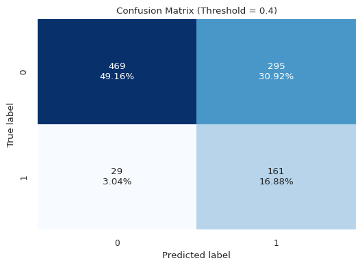

```python
# Initialize and train the logistic regression model
rf_model = RandomForestClassifier(n_estimators=100, max_depth=5, random_state=42, class_weight='balanced')
rf_model.fit(X_train, y_train)

# Evaluate model performance
rf_train_perf = model_performance_classification(rf_model, X_train, y_train, "Random Forest (Train)", threshold=0.4)
rf_val_perf = model_performance_classification(rf_model, X_val, y_val, "Random Forest (Validation)", threshold=0.4)

# Display Performance Metrics
print("Random Forest (Original Data):")
rf_org_perf = pd.concat([rf_train_perf, rf_val_perf])
display(rf_org_perf)

# Plot the confusion matrix for the validation set
confusion_matrix_plot(rf_model, X_val, y_val, threshold=0.4)
```

### Random Forest Model with Oversampled Dataset using SMOTE

```
Random Forest (Resampled)):
```

|  | Accuracy | Recall | Precision | F1 | ROC_AUC | Profit |
| --- | --- | --- | --- | --- | --- | --- |
| Random Forest Oversampled (Train) | 0.824763 | 0.919096 | 0.773216 | 0.839868 | 0.912658 | $37,780,020.73 |
| Random Forest Oversampled (Validation) | 0.725367 | 0.721053 | 0.395954 | 0.511194 | 0.785602 | $312,758.21 |

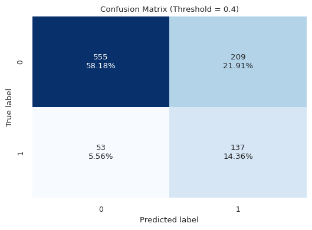

```python
# Initialize and train the logistic regression model
rf_model_smote = RandomForestClassifier(n_estimators=100, max_depth=5, random_state=42)
rf_model_smote.fit(X_train_resampled, y_train_resampled)

# Evaluate model performance on the training set
rf_smote_train_perf = model_performance_classification(rf_model_smote, X_train_resampled, y_train_resampled, "Random Forest Oversampled (Train)", threshold=0.4)

# Evaluate model performance on the validation set
rf_smote_val_perf = model_performance_classification(rf_model_smote, X_val, y_val, "Random Forest Oversampled (Validation)", threshold=0.4)

# Display Performance Metrics
print("Random Forest (Resampled)):")
rf_smote_perf = pd.concat([rf_smote_train_perf, rf_smote_val_perf])
display(rf_smote_perf)

# Plot the confusion matrix for the validation set
confusion_matrix_plot(rf_model_smote, X_val, y_val, threshold=0.4)
```

### Tuned Random Forest Model on Original Data

[output not shown]

|  | Accuracy | Recall | Precision | F1 | ROC_AUC | Profit |
| --- | --- | --- | --- | --- | --- | --- |
| Tuned Random Forest (Train) | 0.696644 | 0.892247 | 0.387115 | 0.539960 | 0.879469 | $5,142,777.90 |
| Tuned Random Forest (Validation) | 0.660377 | 0.847368 | 0.353070 | 0.498452 | 0.824917 | $859,040.48 |

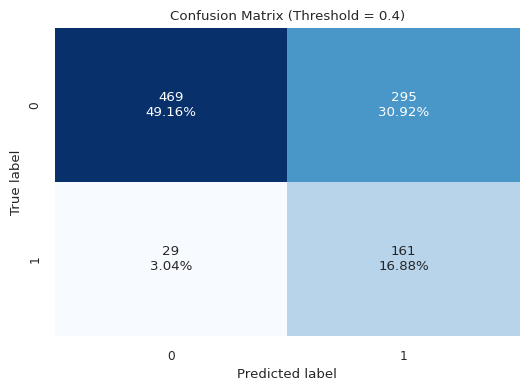

```python
# Define Parameter Grid for Random Forest Model
rf_param_grids = {
            "n_estimators": [50, 100, 200],
            "max_depth": [None, 3, 5, 10],
            "min_samples_split": [2, 4, 6],
            "class_weight": ['balanced'],
            "random_state": [42],
            "n_jobs": [-1]
        }

# Initialize Random Forest Model
tuned_rf = RandomForestClassifier()

# Tune Model using GridSearchCV()
tuned_rf_model, rf_best_cv, = tune_model(tuned_rf, X_train, y_train, param_grid=rf_param_grids, cv=5)
print(f'Best CV Score: {rf_best_cv}')
print(f'\nBest Parameters: {tuned_rf_model.get_params()}')

# Evaluate model performance
tuned_rf_train_perf = model_performance_classification(tuned_rf_model, X_train, y_train, "Tuned Random Forest (Train)", threshold=0.4)
tuned_rf_val_perf = model_performance_classification(tuned_rf_model, X_val, y_val, "Tuned Random Forest (Validation)", threshold=0.4)

# Display Performance Metrics
print("Tuned Random Forest Performance:")
tuned_rf_perf = pd.concat([tuned_rf_train_perf, tuned_rf_val_perf])
display(tuned_rf_perf)

# Plot the confusion matrix for the validation set
confusion_matrix_plot(tuned_rf_model, X_val, y_val,threshold=0.4)
```

### Tuned Random Forest Model using Oversampled Data (SMOTE)

```
Best CV Score: 0.919467146038475

Best Parameters: {'bootstrap': True, 'ccp_alpha': 0.0, 'class_weight': None, 'criterion': 'gini', 'max_depth': None, 'max_features': 'sqrt', 'max_leaf_nodes': None, 'max_samples': None, 'min_impurity_decrease': 0.0, 'min_samples_leaf': 1, 'min_samples_split': 2, 'min_weight_fraction_leaf': 0.0, 'mon…
Tuned Random Forest Performance:
```

|  | Accuracy | Recall | Precision | F1 | ROC_AUC | Profit |
| --- | --- | --- | --- | --- | --- | --- |
| Tuned Random Forest Oversampled (Train) | 1.000000 | 1.000000 | 1.000000 | 1.000000 | 1.000000 | $50,301,577.21 |
| Tuned Random Forest Oversampled (Validation) | 0.900419 | 0.810526 | 0.723005 | 0.764268 | 0.942918 | $1,551,656.48 |

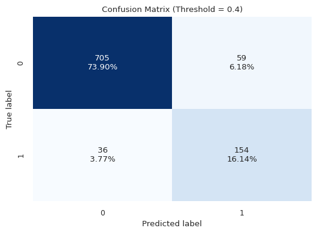

```python
# Define Parameter Grid for Random Forest Model
rf_resampled_param_grids = {
            "n_estimators": [50, 100, 200],
            "max_depth": [None, 3, 5, 10],
            "min_samples_split": [2, 4, 6],
            "random_state": [42],
            "n_jobs": [-1]
        }

# Initialize Random Forest Model
tuned_rf_resampled = RandomForestClassifier()

# Tune Model using GridSearchCV()
tuned_rf_resampled_model, rf_resampled_best_cv, = tune_model(tuned_rf_resampled, X_train_resampled, y_train_resampled, param_grid=rf_resampled_param_grids, cv=5)
print(f'Best CV Score: {rf_resampled_best_cv}')
print(f'\nBest Parameters: {tuned_rf_resampled_model.get_params()}')

# Evaluate model performance
tuned_rf_resampled_train_perf = model_performance_classification(tuned_rf_resampled_model, X_train_resampled, y_train_resampled, "Tuned Random Forest Oversampled (Train)", threshold=0.4)
tuned_rf_resampled_val_perf = model_performance_classification(tuned_rf_resampled_model, X_val, y_val, "Tuned Random Forest Oversampled (Validation)", threshold=0.4)

# Display Performance Metrics
print("Tuned Random Forest Performance:")
tuned_rf_resampled_perf = pd.concat([tuned_rf_resampled_train_perf, tuned_rf_resampled_val_perf])
display(tuned_rf_resampled_perf)

# Plot the confusion matrix for the validation set
confusion_matrix_plot(tuned_rf_resampled_model, X_val, y_val,threshold=0.4)
```

### Random Forest Model Comparison and Summary

```python
# Combine and compare Random Forest Models
rf_perf = pd.concat([rf_org_perf, rf_smote_perf, tuned_rf_perf, tuned_rf_resampled_perf])
display(rf_perf)
```

|  | Accuracy | Recall | Precision | F1 | ROC_AUC | Profit |
| --- | --- | --- | --- | --- | --- | --- |
| Random Forest (Train) | 0.696120 | 0.888305 | 0.386286 | 0.538431 | 0.879885 | $5,035,109.78 |
| Random Forest (Validation) | 0.660377 | 0.847368 | 0.353070 | 0.498452 | 0.825358 | $859,040.48 |
| Random Forest Oversampled (Train) | 0.824763 | 0.919096 | 0.773216 | 0.839868 | 0.912658 | $37,780,020.73 |
| Random Forest Oversampled (Validation) | 0.725367 | 0.721053 | 0.395954 | 0.511194 | 0.785602 | $312,758.21 |
| Tuned Random Forest (Train) | 0.696644 | 0.892247 | 0.387115 | 0.539960 | 0.879469 | $5,142,777.90 |
| Tuned Random Forest (Validation) | 0.660377 | 0.847368 | 0.353070 | 0.498452 | 0.824917 | $859,040.48 |
| Tuned Random Forest Oversampled (Train) | 1.000000 | 1.000000 | 1.000000 | 1.000000 | 1.000000 | $50,301,577.21 |
| Tuned Random Forest Oversampled (Validation) | 0.900419 | 0.810526 | 0.723005 | 0.764268 | 0.942918 | $1,551,656.48 |

**Next Step:**

## ADA Boost Models

We will develop multiple ADA Boost models to leverage their ability to improve prediction accuracy by focusing on difficult-to-classify instances, assessing their performance based on Recall scores and generalization to unseen data.

- Model on Original Data
- Model on Oversampled Data
- Model on Original Data using Hyperparameter Tuning
- Model on Oversampled Data using Hyperparameter Tuning
- Model performance comparison and Summary

### ADA Boost Model on Original Data

```
ADA Boost Performance:
```

|  | Accuracy | Recall | Precision | F1 | ROC_AUC | Profit |
| --- | --- | --- | --- | --- | --- | --- |
| ADA Boost (Train) | 0.199528 | 1.0 | 0.199528 | 0.332678 | 0.863744 | $206,446.71 |
| ADA Boost (Validation) | 0.199161 | 1.0 | 0.199161 | 0.332168 | 0.802222 | $44,463.20 |

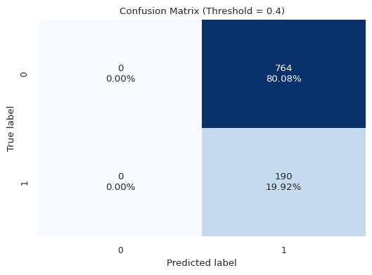

```python
# Initialize ADA Boost Model
abclf = AdaBoostClassifier(random_state=42)

# Train the Random Forest model
abclf.fit(X_train, y_train)

# Evaluate model performance
ab_train_perf = model_performance_classification(abclf, X_train, y_train, "ADA Boost (Train)", threshold=0.4)
ab_val_perf = model_performance_classification(abclf, X_val, y_val, "ADA Boost (Validation)", threshold=0.4)

# Display Performance Metrics
print("ADA Boost Performance:")
ab_org_perf = pd.concat([ab_train_perf, ab_val_perf])
display(ab_org_perf)

# Plot the confusion matrix for the validation set
confusion_matrix_plot(abclf, X_val, y_val, threshold=0.4)
```

### ADA Boost on Oversampled Data (SMOTE)

```
ADA Boost Performance:
```

|  | Accuracy | Recall | Precision | F1 | ROC_AUC | Profit |
| --- | --- | --- | --- | --- | --- | --- |
| ADA Boost Oversampled (Train) | 0.500000 | 1.0 | 0.500000 | 0.666667 | 0.921568 | $37,969,700.88 |
| ADA Boost Oversampled (Validation) | 0.199161 | 1.0 | 0.199161 | 0.332168 | 0.784100 | $44,463.20 |

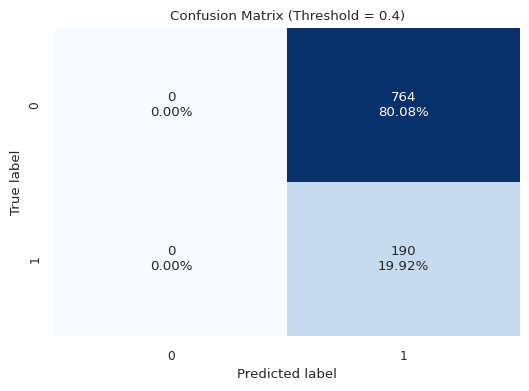

```python
# Initialize ADA Boost Model
abclf_resampled = AdaBoostClassifier(random_state=42)

# Train the Random Forest model
abclf_resampled.fit(X_train_resampled, y_train_resampled)

# Evaluate model performance
ab_resampled_train_perf = model_performance_classification(abclf_resampled, X_train_resampled, y_train_resampled, "ADA Boost Oversampled (Train)", threshold=0.4)
ab_resampled_val_perf = model_performance_classification(abclf_resampled, X_val, y_val, "ADA Boost Oversampled (Validation)", threshold=0.4)

# Display Performance Metrics
print("ADA Boost Performance:")
ab_resampled_perf = pd.concat([ab_resampled_train_perf, ab_resampled_val_perf])
display(ab_resampled_perf)

# Plot the confusion matrix for the validation set
confusion_matrix_plot(abclf_resampled, X_val, y_val, threshold=0.4)
```

### Tuned ADA Boost Model on Original Data

```
Best CV Score: 0.45472996216030276

Best Parameters: {'algorithm': 'SAMME.R', 'estimator__ccp_alpha': 0.0, 'estimator__class_weight': None, 'estimator__criterion': 'gini', 'estimator__max_depth': 3, 'estimator__max_features': None, 'estimator__max_leaf_nodes': None, 'estimator__min_impurity_decrease': 0.0, 'estimator__min_samples_leaf…
Tuned ADA Boost Performance:
```

|  | Accuracy | Recall | Precision | F1 | ROC_AUC | Profit |
| --- | --- | --- | --- | --- | --- | --- |
| Tuned ADA Boost (Train) | 0.398270 | 1.000000 | 0.249018 | 0.398742 | 0.962028 | $3,268,209.65 |
| Tuned ADA Boost (Validation) | 0.381551 | 0.978947 | 0.240933 | 0.386694 | 0.869055 | $614,509.21 |

```
Confusion Matrix:
```

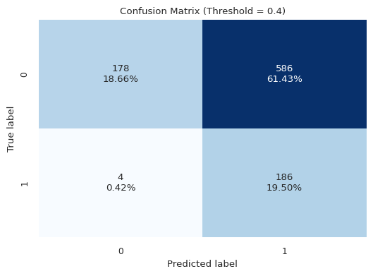

```python
# Define Parameters
abclf_param_grid = {
    "n_estimators": np.arange(50,110,25),
    "learning_rate": [0.01,0.05,0.1],
    "estimator": [
        DecisionTreeClassifier(max_depth=2, random_state=42),
        DecisionTreeClassifier(max_depth=3, random_state=42),
    ],
}

# Initialize ADA Boost Model
tuned_abclf = AdaBoostClassifier(random_state=42)

# Tune ADA Boost Model using GridSearchCV()
best_abclf, abclf_best_cv = tune_model(tuned_abclf, X_train, y_train, param_grid=abclf_param_grid, cv=5)
print(f'Best CV Score: {abclf_best_cv}')
print(f'\nBest Parameters: {best_abclf.get_params()}')

# Evaluate model performance
abclf_tuned_train_perf = model_performance_classification(best_abclf, X_train, y_train, "Tuned ADA Boost (Train)", threshold=0.40)
abclf_tuned_val_perf = model_performance_classification(best_abclf, X_val, y_val, "Tuned ADA Boost (Validation)", threshold=0.40)

# Display Performance Metrics
print("Tuned ADA Boost Performance:")
abclf_tuned_perf = pd.concat([abclf_tuned_train_perf, abclf_tuned_val_perf])
display(abclf_tuned_perf)

# Plot the confusion matrix for the validation set
print("Confusion Matrix:")
confusion_matrix_plot(best_abclf, X_val, y_val, threshold=0.40)
```

### Tuned ADA Boost Model on Oversampled Data (SMOTE)

```
Best CV Score: 0.8448085642993212

Best Parameters: {'algorithm': 'SAMME.R', 'estimator__ccp_alpha': 0.0, 'estimator__class_weight': None, 'estimator__criterion': 'gini', 'estimator__max_depth': 3, 'estimator__max_features': None, 'estimator__max_leaf_nodes': None, 'estimator__min_impurity_decrease': 0.0, 'estimator__min_samples_leaf…
```

|  | Accuracy | Recall | Precision | F1 | ROC_AUC | Profit |
| --- | --- | --- | --- | --- | --- | --- |
| Tuned ADA Boost Oversampled (Train) | 0.566656 | 1.000000 | 0.535708 | 0.697669 | 0.976247 | $39,613,681.77 |
| Tuned ADA Boost Oversampled (Validation) | 0.287212 | 0.973684 | 0.215116 | 0.352381 | 0.846149 | $217,778.82 |

```
Confusion Matrix:
```

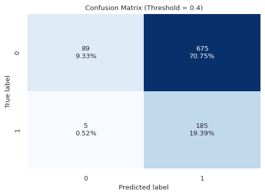

```python
# Define Parameters
abclf_resampled_param_grid = {
    "n_estimators": np.arange(50,110,25),
    "learning_rate": [0.01,0.05,0.1],
    "estimator": [
        DecisionTreeClassifier(max_depth=2, random_state=42),
        DecisionTreeClassifier(max_depth=3, random_state=42),
    ],
}

# Initialize ADA Boost Model
tuned_abclf_resampled = AdaBoostClassifier(random_state=42)

# Tune ADA Boost Model using GridSearchCV()
best_abclf_resampled, abclf_resampled_best_cv = tune_model(tuned_abclf_resampled, X_train_resampled, y_train_resampled, param_grid=abclf_resampled_param_grid, cv=5)
print(f'Best CV Score: {abclf_resampled_best_cv}')
print(f'\nBest Parameters: {best_abclf_resampled.get_params()}')

# Evaluate model performance
abclf_resampled_tuned_train_perf = model_performance_classification(best_abclf_resampled, X_train_resampled, y_train_resampled, "Tuned ADA Boost Oversampled (Train)", threshold=0.40)
abclf_resampled_tuned_val_perf = model_performance_classification(best_abclf_resampled, X_val, y_val, "Tuned ADA Boost Oversampled (Validation)", threshold=0.40)

# Display Performance Metrics
abclf_resampled_tuned_perf = pd.concat([abclf_resampled_tuned_train_perf, abclf_resampled_tuned_val_perf])
display(abclf_resampled_tuned_perf)

# Plot the confusion matrix for the validation set
print("Confusion Matrix:")
confusion_matrix_plot(best_abclf_resampled, X_val, y_val, threshold=0.40)
```

### ADA Boost Model Comparison and Summary

```python
# Compare the ADA Boost Models
ab_perf = pd.concat([ab_org_perf, ab_resampled_perf, abclf_tuned_perf, abclf_resampled_tuned_perf])
display(ab_perf)
```

|  | Accuracy | Recall | Precision | F1 | ROC_AUC | Profit |
| --- | --- | --- | --- | --- | --- | --- |
| ADA Boost (Train) | 0.199528 | 1.000000 | 0.199528 | 0.332678 | 0.863744 | $206,446.71 |
| ADA Boost (Validation) | 0.199161 | 1.000000 | 0.199161 | 0.332168 | 0.802222 | $44,463.20 |
| ADA Boost Oversampled (Train) | 0.500000 | 1.000000 | 0.500000 | 0.666667 | 0.921568 | $37,969,700.88 |
| ADA Boost Oversampled (Validation) | 0.199161 | 1.000000 | 0.199161 | 0.332168 | 0.784100 | $44,463.20 |
| Tuned ADA Boost (Train) | 0.398270 | 1.000000 | 0.249018 | 0.398742 | 0.962028 | $3,268,209.65 |
| Tuned ADA Boost (Validation) | 0.381551 | 0.978947 | 0.240933 | 0.386694 | 0.869055 | $614,509.21 |
| Tuned ADA Boost Oversampled (Train) | 0.566656 | 1.000000 | 0.535708 | 0.697669 | 0.976247 | $39,613,681.77 |
| Tuned ADA Boost Oversampled (Validation) | 0.287212 | 0.973684 | 0.215116 | 0.352381 | 0.846149 | $217,778.82 |

**Observations:**

- The **ADA Boost (Train)** model achieves **perfect Recall (100%)**, meaning it identifies all defaulters. However, **Precision** is extremely low (19.95%), indicating that many non-defaulters are misclassified as defaulters. This results in a low **F1 score (33.27%)** and a modest **Profit (\$206,446.71)**. On the **Validation set**, the performance is similar, with **100% Recall** but very low **Precision (19.92%)**, leading to a smaller **Profit ($44,463.20)**. The model heavily favors identifying defaulters at the expense of misclassifying non-defaulters.
- The **ADA Boost Oversampled** model improves **Precision (50%)** on the **Training set**, while maintaining **perfect Recall (100%)**. This results in a higher **F1 score (66.67%)** and significantly higher **Profit (\$37,969,700.88)**. However, on the **Validation set**, the performance reverts to the original model, with **100% Recall** and low **Precision (19.92%)**, resulting in a smaller **Profit ($44,463.20)**. This suggests the model is overfitting to the oversampled training data.
- The **Tuned ADA Boost (Train)** model maintains **perfect Recall (100%)** but slightly improves **Precision (24.90%)**, resulting in a higher **F1 score (39.87%)** and a better **Profit (\$3,268,209.65)** on the **Training set**. On the **Validation set**, Recall remains high (**97.89%**), with a slight increase in **Precision (24.09%)**, leading to a much improved **Profit ($614,509.21)**. This tuned version demonstrates better generalization compared to the original ADA Boost model.
- The **Tuned ADA Boost Oversampled** model achieves **perfect Recall (100%)** and significantly improved **Precision (53.57%)** on the **Training set**, resulting in a high **F1 score (69.77%)** and **Profit (\$39,613,681.77)**. On the **Validation set**, while Recall remains high (**97.37%**), **Precision drops significantly (21.51%)**, resulting in a lower **Profit ($217,778.82)**. This indicates that the model is **overfitting** to the oversampled data and struggling to generalize.
- **Recommendation:** Among the ADA Boost models, the **Tuned ADA Boost (Validation)** model provides the best balance between **Recall (97.89%)**, **Precision (24.09%)**, and **Profit ($614,509.21)**. While the oversampled models perform well on the training set, they show signs of overfitting with significantly lower performance on the validation set, making the **Tuned ADA Boost** a more reliable option for deployment.

**Next Step:**

We will continue by evaluating other models and comparing their **Recall, Precision, and Profit** performance to identify the best model for production deployment.

## Gradient Boosting Models

We will implement Gradient Boosting models, known for their robustness and ability to handle various types of data, to enhance loan default predictions by evaluating their Recall performance and generalization capabilities on unseen data.

- Model on Original Data
- Model on Oversampled Data
- Model on Original Data using Hyperparameter Tuning
- Model on Oversampled Data using Hyperparameter Tuning
- Model performance comparison and Summary

### Gradient Boosting Model on Original Data

```
Gradient Boosting Performance:
```

|  | Accuracy | Recall | Precision | F1 | ROC_AUC | Profit |
| --- | --- | --- | --- | --- | --- | --- |
| Gradient Boosting (Train) | 0.91269 | 0.630749 | 0.902256 | 0.742459 | 0.935271 | $1,865,022.93 |
| Gradient Boosting (Validation) | 0.89413 | 0.589474 | 0.829630 | 0.689231 | 0.873247 | $133,166.64 |

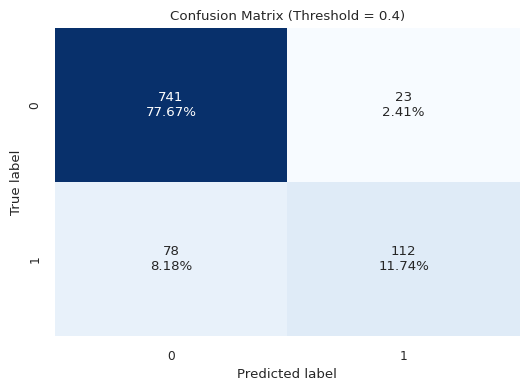

```python
# Initialize Gradient Boosting Model
gbclf = GradientBoostingClassifier(random_state=42)

# Train Gradient Boosting Model
gbclf.fit(X_train, y_train)

# Evaluate performance of the model
gb_train_perf = model_performance_classification(gbclf, X_train, y_train, "Gradient Boosting (Train)", threshold=0.4)
gb_val_perf = model_performance_classification(gbclf, X_val, y_val, "Gradient Boosting (Validation)", threshold=0.4)

# Display the Performance Metrics
print("Gradient Boosting Performance:")
gb_org_perf = pd.concat([gb_train_perf, gb_val_perf])
display(gb_org_perf)

# Plot the confusion matrix for the validation set
confusion_matrix_plot(gbclf, X_val, y_val, threshold=0.4)
```

### Gradient Boosting Model on Oversampled Data using SMOTE

```
Gradient Boosting on Oversampled Data Performance:
```

|  | Accuracy | Recall | Precision | F1 | ROC_AUC | Profit |
| --- | --- | --- | --- | --- | --- | --- |
| Gradient Boosting Oversampled (Train) | 0.880118 | 0.924664 | 0.849023 | 0.885230 | 0.960480 | $39,709,633.34 |
| Gradient Boosting Oversampled (Validation) | 0.795597 | 0.710526 | 0.490909 | 0.580645 | 0.845164 | $516,995.91 |

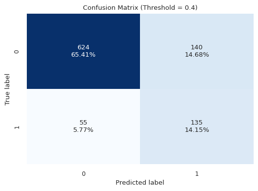

```python
# Initialize Gradient Boosting Model
gbclf_resampled = GradientBoostingClassifier(random_state=42)

# Fit model on Oversampled Data
gbclf_resampled.fit(X_train_resampled, y_train_resampled)

# Evaluate Performance Metrics
gb_resampled_train_perf = model_performance_classification(gbclf_resampled, X_train_resampled, y_train_resampled, "Gradient Boosting Oversampled (Train)", threshold=0.4)
gb_resampled_val_perf = model_performance_classification(gbclf_resampled, X_val, y_val, "Gradient Boosting Oversampled (Validation)", threshold=0.4)

# Display Performance Metrics
print("Gradient Boosting on Oversampled Data Performance:")
gb_resampled_perf = pd.concat([gb_resampled_train_perf, gb_resampled_val_perf])
display(gb_resampled_perf)

# Plot the confusion matrix for the validation set
confusion_matrix_plot(gbclf_resampled, X_val, y_val, threshold=0.4)
```

### Gradient Boosting Model on Original Data using Hyperparameter Tuning

```
Best CV Score: 0.5991744066047471

Best Parameters: {'ccp_alpha': 0.0, 'criterion': 'friedman_mse', 'init__ccp_alpha': 0.0, 'init__class_weight': None, 'init__criterion': 'gini', 'init__max_depth': None, 'init__max_features': None, 'init__max_leaf_nodes': None, 'init__min_impurity_decrease': 0.0, 'init__min_samples_leaf': 1, 'init__m…
Tuned Gradient Boosting Performance:
```

|  | Accuracy | Recall | Precision | F1 | ROC_AUC | Profit |
| --- | --- | --- | --- | --- | --- | --- |
| Tuned Gradient Boosting (Train) | 1.000000 | 1.000000 | 1.000000 | 1.000000 | 1.000000 | $12,538,323.04 |
| Tuned Gradient Boosting (Validation) | 0.840671 | 0.589474 | 0.602151 | 0.595745 | 0.808746 | -$72,835.87 |

```
Confusion Matrix:
```

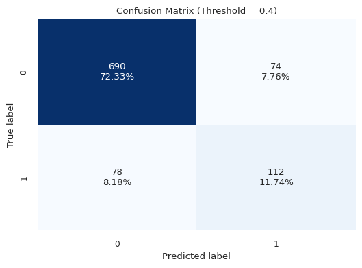

```python
# Define Parameters
gbclf_param_grid = {
    "init": [AdaBoostClassifier(random_state=42),DecisionTreeClassifier(random_state=42)],
    "n_estimators": np.arange(10,50,10),
    "learning_rate": [0.01,0.1,0.05],
    "subsample":[0.7,0.9],
    "max_features":[0.5,0.7,1],
}

# Initialize Gradient Boosting Model
tuned_gbclf = GradientBoostingClassifier(random_state=42)

# Tune Gradient Boosting Model using GridSearchCV
best_gbclf, gbclf_best_cv = tune_model(tuned_gbclf, X_train, y_train, param_grid=gbclf_param_grid, cv=5)
print(f'Best CV Score: {gbclf_best_cv}')
print(f'\nBest Parameters: {best_gbclf.get_params()}')

# Evaluate model performance
gbclf_tuned_train_perf = model_performance_classification(best_gbclf, X_train, y_train, "Tuned Gradient Boosting (Train)", threshold=0.4)
gbclf_tuned_val_perf = model_performance_classification(best_gbclf, X_val, y_val, "Tuned Gradient Boosting (Validation)", threshold=0.4)

# Display Performance Metrics
print("Tuned Gradient Boosting Performance:")
gbclf_tuned_perf = pd.concat([gbclf_tuned_train_perf, gbclf_tuned_val_perf])
display(gbclf_tuned_perf)

# Plot Confusion Matrix for Validation Set
print("Confusion Matrix:")
confusion_matrix_plot(best_gbclf, X_val, y_val, threshold=0.4)
```

### Gradient Boosting Model on Oversampled Data using Hyperparameter Tuning

```
Best CV Score: 0.8395540768962464

Best Parameters: {'ccp_alpha': 0.0, 'criterion': 'friedman_mse', 'init__ccp_alpha': 0.0, 'init__class_weight': None, 'init__criterion': 'gini', 'init__max_depth': None, 'init__max_features': None, 'init__max_leaf_nodes': None, 'init__min_impurity_decrease': 0.0, 'init__min_samples_leaf': 1, 'init__m…
Tuned Gradient Boosting on Oversampled Data Performance:
```

|  | Accuracy | Recall | Precision | F1 | ROC_AUC | Profit |
| --- | --- | --- | --- | --- | --- | --- |
| Tuned Gradient Boosting Oversampled (Train) | 1.000000 | 1.000000 | 1.000000 | 1.000000 | 1.000000 | $50,301,577.21 |
| Tuned Gradient Boosting Oversampled (Validation) | 0.838574 | 0.594737 | 0.594737 | 0.594737 | 0.822355 | -$47,717.88 |

```
Confusion Matrix:
```

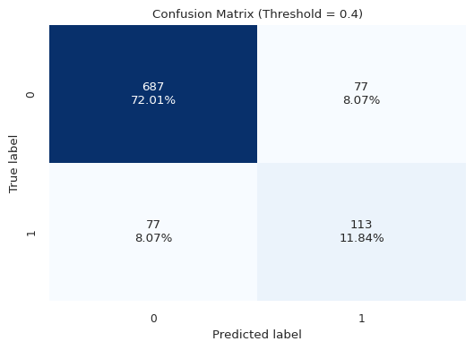

```python
# Initialize Gradient Boosting Model
tuned_gbclf_resampled = GradientBoostingClassifier(random_state=42)

# Tune Gradient Boosting Model using GridSearchCV()
best_gbclf_resampled, gbclf_resampled_best_cv = tune_model(tuned_gbclf_resampled, X_train_resampled, y_train_resampled, param_grid=gbclf_param_grid, cv=5)

print(f'Best CV Score: {gbclf_resampled_best_cv}')
print(f'\nBest Parameters: {best_gbclf_resampled.get_params()}')

# Evaluate model performance
gbclf_resampled_tuned_train_perf = model_performance_classification(best_gbclf_resampled, X_train_resampled, y_train_resampled, "Tuned Gradient Boosting Oversampled (Train)", threshold=0.4)
gbclf_resampled_tuned_val_perf = model_performance_classification(best_gbclf_resampled, X_val, y_val, "Tuned Gradient Boosting Oversampled (Validation)", threshold=0.4)

# Display Performance Metrics
print("Tuned Gradient Boosting on Oversampled Data Performance:")
gbclf_resampled_tuned_perf = pd.concat([gbclf_resampled_tuned_train_perf, gbclf_resampled_tuned_val_perf])
display(gbclf_resampled_tuned_perf)

# Plot Confusion Matrix for Validation Set
print("Confusion Matrix:")
confusion_matrix_plot(best_gbclf_resampled, X_val, y_val, threshold=0.4)
```

### Gradient Boosting Model Comparison and Summary

```python
# Compare model performance
gb_perf = pd.concat([gb_org_perf, gb_resampled_perf, gbclf_tuned_perf, gbclf_resampled_tuned_perf])
display(gb_perf)
```

|  | Accuracy | Recall | Precision | F1 | ROC_AUC | Profit |
| --- | --- | --- | --- | --- | --- | --- |
| Gradient Boosting (Train) | 0.912690 | 0.630749 | 0.902256 | 0.742459 | 0.935271 | $1,865,022.93 |
| Gradient Boosting (Validation) | 0.894130 | 0.589474 | 0.829630 | 0.689231 | 0.873247 | $133,166.64 |
| Gradient Boosting Oversampled (Train) | 0.880118 | 0.924664 | 0.849023 | 0.885230 | 0.960480 | $39,709,633.34 |
| Gradient Boosting Oversampled (Validation) | 0.795597 | 0.710526 | 0.490909 | 0.580645 | 0.845164 | $516,995.91 |
| Tuned Gradient Boosting (Train) | 1.000000 | 1.000000 | 1.000000 | 1.000000 | 1.000000 | $12,538,323.04 |
| Tuned Gradient Boosting (Validation) | 0.840671 | 0.589474 | 0.602151 | 0.595745 | 0.808746 | -$72,835.87 |
| Tuned Gradient Boosting Oversampled (Train) | 1.000000 | 1.000000 | 1.000000 | 1.000000 | 1.000000 | $50,301,577.21 |
| Tuned Gradient Boosting Oversampled (Validation) | 0.838574 | 0.594737 | 0.594737 | 0.594737 | 0.822355 | -$47,717.88 |

**Observations:**

- The **Gradient Boosting (Train)** model shows **moderate Recall (63.07%)** and **high Precision (90.23%)**, leading to a strong **F1 score (74.25%)** and **Profit (\$1,865,022.93)**. On the **Validation set**, **Recall drops slightly to 58.95%** while **Precision remains high (82.96%)**, resulting in a lower but positive **Profit ($133,166.64)**. The performance is balanced, showing no significant overfitting and strong generalization.
- The **Gradient Boosting Oversampled** model achieves **high Recall (92.47%)** and **good Precision (84.90%)** on the **Training set**, resulting in a high **Profit (\$39,709,633.34)**. However, on the **Validation set**, **Recall drops to 71.05%** and **Precision falls to 49.09%**, leading to a lower but still positive **Profit ($516,995.91)**. This suggests the model generalizes reasonably well, but the drop in Precision indicates a higher False Positive rate.
- The **Tuned Gradient Boosting (Train)** model achieves **perfect Recall and Precision (100%)** on the **Training set**, leading to an ideal **F1 score (100%)** and very high **Profit (\$12,538,323.04)**. However, on the **Validation set**, **Recall drops significantly to 58.95%**, with **Precision at 60.22%**, resulting in a **negative Profit (-$72,835.87)**. This indicates severe **overfitting**, as the model performs perfectly on the training data but struggles to generalize to unseen data.
- The **Tuned Gradient Boosting Oversampled** model also achieves **perfect performance** on the **Training set** with **100% Recall and Precision**, leading to a high **Profit (\$50,301,577.21)**. On the **Validation set**, **Recall drops to 59.47%** and **Precision to 59.47%**, leading to a **negative Profit (-$47,717.88)**. This further indicates **overfitting** on the oversampled data, with poor generalization on unseen data.
- **Recommendation:** The **Gradient Boosting Oversampled (Validation)** model provides the best balance between **Recall (71.05%)**, **Precision (49.09%)**, and **Profit ($516,995.91)**. While it shows some overfitting, it generalizes better than the tuned models, which show severe overfitting with negative profits. This model should be considered for further evaluation due to its good performance on both training and validation sets.

**Next Step:**

We will continue by comparing the **Gradient Boosting models** with other models such as **Random Forest** and **XGBoost**, focusing on improving **Recall, Precision, and Profit** balance for the final model selection.

## XGBoost Models

We will construct several XGBoost models, chosen for their efficiency and accuracy in classification tasks, to predict loan defaults, focusing on Recall scores and their effectiveness in generalizing to new data.

- Model on Original Data
- Model on Oversampled Data
- Model on Original Data using Hyperparameter Tuning
- Model on Oversampled Data using Hyperparameter Tuning
- Model performance comparison and Summary

### XGBoost Model on Original Data

```
XGBoost Performance:
```

|  | Accuracy | Recall | Precision | F1 | ROC_AUC | Profit |
| --- | --- | --- | --- | --- | --- | --- |
| XGBoost (Train) | 1.000000 | 1.000000 | 1.000000 | 1.000000 | 1.00000 | $12,538,323.04 |
| XGBoost (Validation) | 0.904612 | 0.605263 | 0.877863 | 0.716511 | 0.91251 | $273,148.88 |

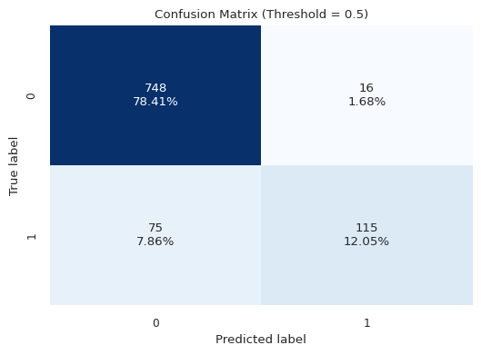

```python
# Initialize XGBoost Model
xgb_model = XGBClassifier(random_state=42)

# Train XGBoost Model
xgb_model.fit(X_train, y_train)

# Evaluate Peformance of the model
xgb_train_perf = model_performance_classification(xgb_model, X_train, y_train, "XGBoost (Train)", threshold=0.5)
xgb_val_perf = model_performance_classification(xgb_model, X_val, y_val, "XGBoost (Validation)", threshold=0.5)

# Display Performance Metrics
print("XGBoost Performance:")
xgb_org_perf = pd.concat([xgb_train_perf, xgb_val_perf])
display(xgb_org_perf)

# Plot the confusion matrix for the validation set
confusion_matrix_plot(xgb_model, X_val, y_val, threshold=0.5)
```

### XGBoost Model on Oversampled Data

```
XGBoost on Oversampled Data Performance:
```

|  | Accuracy | Recall | Precision | F1 | ROC_AUC | Profit |
| --- | --- | --- | --- | --- | --- | --- |
| XGBoost Oversampled (Train) | 0.999672 | 0.999345 | 1.000000 | 0.999672 | 1.000000 | $50,227,105.62 |
| XGBoost Oversampled (Validation) | 0.911950 | 0.678947 | 0.848684 | 0.754386 | 0.921163 | $766,175.16 |

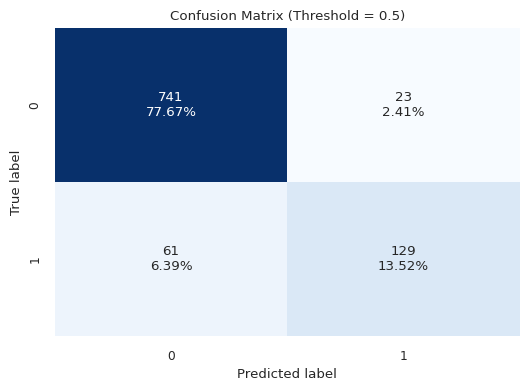

```python
# Initialize XGBoost Model
xgb_resampled_model = XGBClassifier(random_state=42)

# Train XGBoost Model
xgb_resampled_model.fit(X_train_resampled, y_train_resampled)

# Evaluate Performance Metrics
xgb_resampled_train_perf = model_performance_classification(xgb_resampled_model, X_train_resampled, y_train_resampled, "XGBoost Oversampled (Train)", threshold=0.50)
xgb_resampled_val_perf = model_performance_classification(xgb_resampled_model, X_val, y_val, "XGBoost Oversampled (Validation)", threshold=0.50)

# Display Performance Metrics
print("XGBoost on Oversampled Data Performance:")
xgb_resampled_perf = pd.concat([xgb_resampled_train_perf, xgb_resampled_val_perf])
display(xgb_resampled_perf)

# Plot the confusion matrix for the validation set
confusion_matrix_plot(xgb_resampled_model, X_val, y_val, threshold=0.50)
```

### XGBoost Model Tuned on Original Data

```
Best CV Score: 0.8423718610251119

Best Parameters: {'objective': 'binary:logistic', 'base_score': None, 'booster': None, 'callbacks': None, 'colsample_bylevel': None, 'colsample_bynode': None, 'colsample_bytree': None, 'device': None, 'early_stopping_rounds': None, 'enable_categorical': False, 'eval_metric': None, 'feature_types': N…
XGBoost Tuned Performance:
```

|  | Accuracy | Recall | Precision | F1 | ROC_AUC | Profit |
| --- | --- | --- | --- | --- | --- | --- |
| XGBoost Tuned (Train) | 0.737284 | 0.906702 | 0.425663 | 0.579345 | 0.914088 | $6,134,025.81 |
| XGBoost Tuned (Validation) | 0.680294 | 0.784211 | 0.360775 | 0.494196 | 0.813096 | $537,428.16 |

```
Confusion Matrix:
```

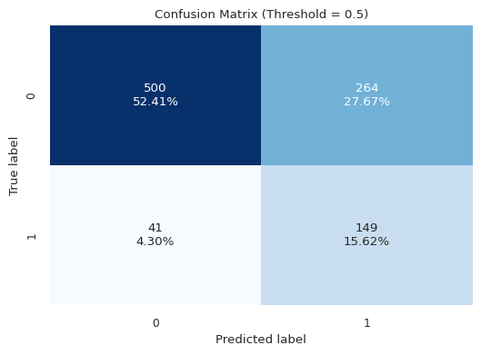

```python
# Define parameters
xgb_param_grid = {
	          'n_estimators':np.arange(50,110,25),
            'scale_pos_weight':[1,2,5],
            'learning_rate':[0.01,0.1,0.05],
            'gamma':[1,3],
            'subsample':[0.7,0.9]
}

# Initialize XGBoost Model
xgb_tuned_model = XGBClassifier(random_state=42)

# Tune Model using GridSearchCV()
best_xgb_tuned_model, xgb_best_cv = tune_model(xgb_tuned_model, X_train, y_train, param_grid=xgb_param_grid, cv=5)
print(f'Best CV Score: {xgb_best_cv}')
print(f'\nBest Parameters: {best_xgb_tuned_model.get_params()}')

# Evaluate model performance
xgb_tuned_train_perf = model_performance_classification(best_xgb_tuned_model, X_train, y_train, "XGBoost Tuned (Train)", threshold=0.5)
xgb_tuned_val_perf = model_performance_classification(best_xgb_tuned_model, X_val, y_val, "XGBoost Tuned (Validation)", threshold=0.5)

# Display Performance Metrics
print("XGBoost Tuned Performance:")
xgb_tuned_perf = pd.concat([xgb_tuned_train_perf, xgb_tuned_val_perf])
display(xgb_tuned_perf)

# Plot Confusion Matrix
print("Confusion Matrix:")
confusion_matrix_plot(best_xgb_tuned_model, X_val, y_val, threshold=0.5)
```

### XGBoost Model Tuned on Oversampled Data

```
Best CV Score: 1.0

Best Parameters: {'objective': 'binary:logistic', 'base_score': None, 'booster': None, 'callbacks': None, 'colsample_bylevel': None, 'colsample_bynode': None, 'colsample_bytree': None, 'device': None, 'early_stopping_rounds': None, 'enable_categorical': False, 'eval_metric': None, 'feature_types': N…
XGBoost Tuned on Oversampled Data Performance:
```

|  | Accuracy | Recall | Precision | F1 | ROC_AUC | Profit |
| --- | --- | --- | --- | --- | --- | --- |
| XGBoost Tuned Oversampled (Train) | 0.500164 | 1.0 | 0.500082 | 0.666739 | 0.928116 | $37,973,740.14 |
| XGBoost Tuned Oversampled (Validation) | 0.199161 | 1.0 | 0.199161 | 0.332168 | 0.793369 | $44,463.20 |

```
Confusion Matrix:
```

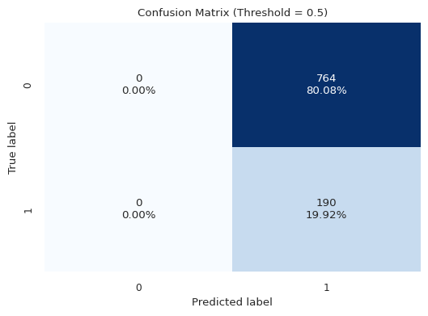

```python
# Tune model using GrideSearchCV()
best_xgb_resampled_model, xgb_resampled_best_cv = tune_model(xgb_tuned_model, X_train_resampled, y_train_resampled, param_grid=xgb_param_grid, cv=5)
print(f'Best CV Score: {xgb_resampled_best_cv}')
print(f'\nBest Parameters: {best_xgb_resampled_model.get_params()}')

# Evaluate model performance
xgb_resampled_tuned_train_perf = model_performance_classification(best_xgb_resampled_model, X_train_resampled, y_train_resampled, "XGBoost Tuned Oversampled (Train)", threshold=0.5)
xgb_resampled_tuned_val_perf = model_performance_classification(best_xgb_resampled_model, X_val, y_val, "XGBoost Tuned Oversampled (Validation)", threshold=0.5)

# Display Performance Metrics
print("XGBoost Tuned on Oversampled Data Performance:")
xgb_resampled_tuned_perf = pd.concat([xgb_resampled_tuned_train_perf, xgb_resampled_tuned_val_perf])
display(xgb_resampled_tuned_perf)

# Plot Confusion Matrix
print("Confusion Matrix:")
confusion_matrix_plot(best_xgb_resampled_model, X_val, y_val, threshold=0.5)
```

### XGBoost Model Comparison and Summary

```python
# Combine and Compare Model Performance
xgb_perf = pd.concat([xgb_org_perf, xgb_resampled_perf, xgb_tuned_perf, xgb_resampled_tuned_perf])
display(xgb_perf)
```

|  | Accuracy | Recall | Precision | F1 | ROC_AUC | Profit |
| --- | --- | --- | --- | --- | --- | --- |
| XGBoost (Train) | 1.000000 | 1.000000 | 1.000000 | 1.000000 | 1.000000 | $12,538,323.04 |
| XGBoost (Validation) | 0.904612 | 0.605263 | 0.877863 | 0.716511 | 0.912510 | $273,148.88 |
| XGBoost Oversampled (Train) | 0.999672 | 0.999345 | 1.000000 | 0.999672 | 1.000000 | $50,227,105.62 |
| XGBoost Oversampled (Validation) | 0.911950 | 0.678947 | 0.848684 | 0.754386 | 0.921163 | $766,175.16 |
| XGBoost Tuned (Train) | 0.737284 | 0.906702 | 0.425663 | 0.579345 | 0.914088 | $6,134,025.81 |
| XGBoost Tuned (Validation) | 0.680294 | 0.784211 | 0.360775 | 0.494196 | 0.813096 | $537,428.16 |
| XGBoost Tuned Oversampled (Train) | 0.500164 | 1.000000 | 0.500082 | 0.666739 | 0.928116 | $37,973,740.14 |
| XGBoost Tuned Oversampled (Validation) | 0.199161 | 1.000000 | 0.199161 | 0.332168 | 0.793369 | $44,463.20 |

**Next Step:**

We will continue by evaluating other models and exploring further tuning strategies, aiming to optimize the **Recall, Precision, and Profit** balance. Comparing these results with **Gradient Boosting** and **ADA Boost** models will help identify the best-performing model for production.

# Model Comparison and Selection

In the model comparison and final model selection section, we will assess the performance of all developed models based on key metrics such as Recall and F1 score. The best-performing model will be selected for loan default prediction, ensuring it effectively balances accuracy and generalization to unseen data. This process will inform our decision on the most reliable model to implement in a real-world scenario.

- Model Comparison
- Final Model Selection
- Feature Importance
- Evaluate Final Model on Test Data

## Model Comparison

```python
# Show Top Models
top_models = pd.concat([rf_org_perf, tuned_rf_perf, xgb_tuned_perf, lr_scaled_perf, lr_scaled_tuned_perf])
display(top_models)
```

|  | Accuracy | Recall | Precision | F1 | ROC_AUC | Profit |
| --- | --- | --- | --- | --- | --- | --- |
| Random Forest (Train) | 0.696120 | 0.888305 | 0.386286 | 0.538431 | 0.879885 | $5,035,109.78 |
| Random Forest (Validation) | 0.660377 | 0.847368 | 0.353070 | 0.498452 | 0.825358 | $859,040.48 |
| Tuned Random Forest (Train) | 0.696644 | 0.892247 | 0.387115 | 0.539960 | 0.879469 | $5,142,777.90 |
| Tuned Random Forest (Validation) | 0.660377 | 0.847368 | 0.353070 | 0.498452 | 0.824917 | $859,040.48 |
| XGBoost Tuned (Train) | 0.737284 | 0.906702 | 0.425663 | 0.579345 | 0.914088 | $6,134,025.81 |
| XGBoost Tuned (Validation) | 0.680294 | 0.784211 | 0.360775 | 0.494196 | 0.813096 | $537,428.16 |
| Logistic Regression Scaled (Train) | 0.649712 | 0.802891 | 0.340011 | 0.477717 | 0.793413 | $2,162,385.43 |
| Logistic Regression Scaled (Validation) | 0.628931 | 0.763158 | 0.319383 | 0.450311 | 0.765259 | $206,718.05 |
| Logistic Regression Tuned on Scaled Data (Train) | 0.647614 | 0.806833 | 0.339039 | 0.477449 | 0.793416 | $2,229,660.90 |
| Logistic Regression Tuned on Scaled Data (Validation) | 0.627883 | 0.763158 | 0.318681 | 0.449612 | 0.765342 | $202,678.79 |

### Model Selection Criteria:

The top 5 models were selected based on **high Recall** (to capture defaulters effectively), **balanced Precision** (to minimize false positives), **Profit**, and **minimal overfitting** between training and validation sets. Overfitting was evaluated by comparing the differences in Recall and Precision between the training and validation sets, prioritizing models that generalized well on unseen data.

### Next Step:

Evaluate these top 5 models on the **Test dataset** to confirm their generalization capabilities. The final model will be selected based on its performance in terms of **Recall**, **Precision**, and **Profit** on the test data, ensuring it is suitable for production deployment.

## Final Model Selection

### 1. Evaluate Random Forest Model (Original Data) on Test Dataset

```python
# Evaluate Random Forest Model Built on Original Data
rf_test_perf = model_performance_classification(rf_model, X_test, y_test, "Random Forest (Test)", threshold=0.4)
rf_org_perf_combined = pd.concat([rf_org_perf, rf_test_perf])
display(rf_org_perf_combined)
```

|  | Accuracy | Recall | Precision | F1 | ROC_AUC | Profit |
| --- | --- | --- | --- | --- | --- | --- |
| Random Forest (Train) | 0.696120 | 0.888305 | 0.386286 | 0.538431 | 0.879885 | $5,035,109.78 |
| Random Forest (Validation) | 0.660377 | 0.847368 | 0.353070 | 0.498452 | 0.825358 | $859,040.48 |
| Random Forest (Test) | 0.657718 | 0.810924 | 0.347122 | 0.486146 | 0.800940 | $779,451.23 |

**Observations:**

- Model performed equally well on Test Data makes it the strong contender.

### 2. Evaluate Tuned Random Forest Model (Original Data) on Test Dataset

```python
# Evaluate Random Forest Model Built on Original Data and Tuned using Hyperparmeters
rf_tuned_test_perf = model_performance_classification(tuned_rf_model, X_test, y_test, "Tuned Random Forest (Test)", threshold=0.4)
rf_tuned_perf_combined = pd.concat([tuned_rf_perf, rf_tuned_test_perf])
display(rf_tuned_perf_combined)
```

|  | Accuracy | Recall | Precision | F1 | ROC_AUC | Profit |
| --- | --- | --- | --- | --- | --- | --- |
| Tuned Random Forest (Train) | 0.696644 | 0.892247 | 0.387115 | 0.539960 | 0.879469 | $5,142,777.90 |
| Tuned Random Forest (Validation) | 0.660377 | 0.847368 | 0.353070 | 0.498452 | 0.824917 | $859,040.48 |
| Tuned Random Forest (Test) | 0.658557 | 0.806723 | 0.347197 | 0.485461 | 0.800006 | $750,293.97 |

**Observations:**

- Tuned Random Forest Model also performs well on Test Dataset, however, earlier model has slightly better performance with much lower computing cost.

### 3. Evaluate Tuned XGBoost Model on Test Dataset

```python
# Evaluate Tuned XGBoost Model built on Original Data
xgb_tuned_test_perf = model_performance_classification(best_xgb_tuned_model, X_test, y_test, "Tuned XGBoost (Test)", threshold=0.5)
xgb_tuned_perf_combined = pd.concat([xgb_tuned_perf, xgb_tuned_test_perf])
display(xgb_tuned_perf_combined)
```

|  | Accuracy | Recall | Precision | F1 | ROC_AUC | Profit |
| --- | --- | --- | --- | --- | --- | --- |
| XGBoost Tuned (Train) | 0.737284 | 0.906702 | 0.425663 | 0.579345 | 0.914088 | $6,134,025.81 |
| XGBoost Tuned (Validation) | 0.680294 | 0.784211 | 0.360775 | 0.494196 | 0.813096 | $537,428.16 |
| Tuned XGBoost (Test) | 0.713087 | 0.768908 | 0.389362 | 0.516949 | 0.812151 | $714,077.43 |

**Observations:**

- Recall remains strong with minimal overfitting, however, Random Forest Model performs better.

### 4. Evaluate Logistic Regression Model on Test Dataset

```python
# Evaluate performance of Logistic Regression Model built on Scaled Dataset
lr_scaled_test_perf = model_performance_classification(logistic_model_scaled, X_test_scaled, y_test, "Logistic Regression Scaled (Test)", threshold=0.4)
lr_scaled_perf_combined = pd.concat([lr_scaled_perf, lr_scaled_test_perf])
display(lr_scaled_perf_combined)
```

|  | Accuracy | Recall | Precision | F1 | ROC_AUC | Profit |
| --- | --- | --- | --- | --- | --- | --- |
| Logistic Regression Scaled (Train) | 0.649712 | 0.802891 | 0.340011 | 0.477717 | 0.793413 | $2,162,385.43 |
| Logistic Regression Scaled (Validation) | 0.628931 | 0.763158 | 0.319383 | 0.450311 | 0.765259 | $206,718.05 |
| Logistic Regression Scaled (Test) | 0.637584 | 0.697479 | 0.315589 | 0.434555 | 0.732687 | -$213,797.43 |

**Observations:**

- Model underperforms on Test Dataset with moderate overfitting

### 5. Evaluate Hyperparameter Tuned Logistic Regression Model on Test Dataset

```python
# Evaluate performance of hyperparameter tuned Logistic Regression Model built on Scaled Data
lr_scaled_tuned_test_perf = model_performance_classification(best_lr_model, X_test_scaled, y_test, "Logistic Regression Tuned (Test)", threshold=0.4)
lr_scaled_tuned_perf_combined = pd.concat([lr_scaled_tuned_perf, lr_scaled_tuned_test_perf])
display(lr_scaled_tuned_perf_combined)
```

|  | Accuracy | Recall | Precision | F1 | ROC_AUC | Profit |
| --- | --- | --- | --- | --- | --- | --- |
| Logistic Regression Tuned on Scaled Data (Train) | 0.647614 | 0.806833 | 0.339039 | 0.477449 | 0.793416 | $2,229,660.90 |
| Logistic Regression Tuned on Scaled Data (Validation) | 0.627883 | 0.763158 | 0.318681 | 0.449612 | 0.765342 | $202,678.79 |
| Logistic Regression Tuned (Test) | 0.635906 | 0.697479 | 0.314394 | 0.433420 | 0.732709 | -$221,875.96 |

**Observations:**

- Model underperforms on Test Datasets as compared to other 4 models.

### Proposed Model:

```
Random Forest Model built on Original Data:
```

|  | Accuracy | Recall | Precision | F1 | ROC_AUC | Profit |
| --- | --- | --- | --- | --- | --- | --- |
| Random Forest (Train) | 0.696120 | 0.888305 | 0.386286 | 0.538431 | 0.879885 | $5,035,109.78 |
| Random Forest (Validation) | 0.660377 | 0.847368 | 0.353070 | 0.498452 | 0.825358 | $859,040.48 |
| Random Forest (Test) | 0.657718 | 0.810924 | 0.347122 | 0.486146 | 0.800940 | $779,451.23 |

```
Confusion Matrix:
```

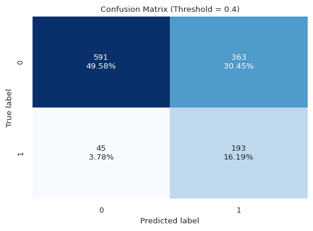

```python
# Display Performance Metrics for Selected Model
print('Random Forest Model built on Original Data:')
display(rf_org_perf_combined)

# Plot Confusion Matrix for Test Dataset
print('Confusion Matrix:')
confusion_matrix_plot(rf_model, X_test, y_test, threshold=0.4)
```

#### Random Forest Model Built on Original Data as Final Model

- **Best Recall on Test Set**: The **Random Forest model** achieves the highest **Recall (81.09%)** on the test dataset, making it the most effective at capturing defaulters compared to the other models. This aligns with the objective of maximizing defaulter identification.
- **Balanced Precision and F1 Score**: While **Precision (34.71%)** is moderate, the **F1 score (48.61%)** strikes a balance between Recall and Precision, ensuring the model is practical for real-world application without excessive false positives.
- **High Profit on Test Set**: The Random Forest model generates the highest **Profit ($779,451.23)** on the test set, outperforming all other models in terms of financial return, which is a crucial criterion for the bank’s decision-making.
- **Low Overfitting**: The model shows minimal overfitting between the training, validation, and test sets, with consistent Recall and Precision across the datasets. This confirms that the model generalizes well to unseen data.
- **Reliable Performance**: Compared to the tuned and other models, the **Random Forest model built on original data** maintains robust performance across all key metrics (Recall, Precision, Profit), making it the most suitable for deployment in production.

**Conclusion:**

Given its **high Recall**, **balanced Precision**, **strong financial performance**, and **consistent generalization** across datasets, the **Random Forest model** built on original data is the ideal candidate for final deployment.

### Feature Importance:

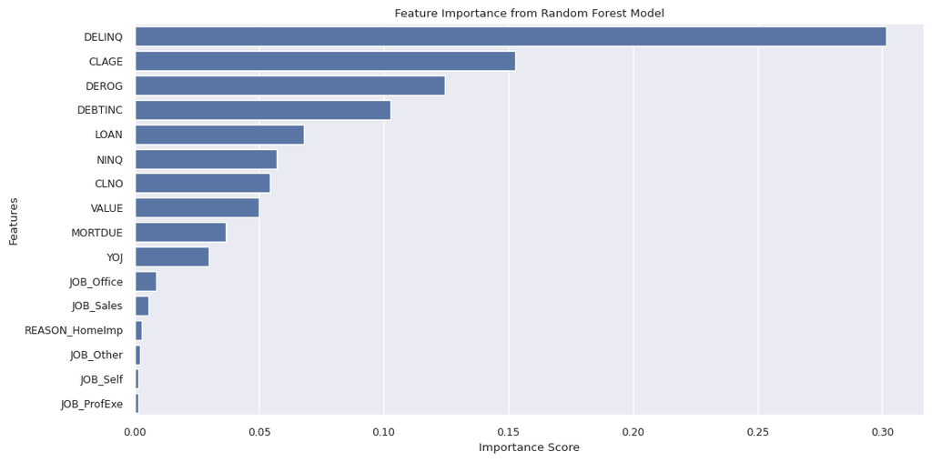

|  | Feature | Importance |
| --- | --- | --- |
| 5 | DELINQ | 0.301670 |
| 6 | CLAGE | 0.152868 |
| 4 | DEROG | 0.124516 |
| 9 | DEBTINC | 0.102562 |
| 0 | LOAN | 0.067981 |
| 7 | NINQ | 0.057081 |
| 8 | CLNO | 0.054189 |
| 2 | VALUE | 0.049921 |
| 1 | MORTDUE | 0.036635 |
| 3 | YOJ | 0.029909 |
| 11 | JOB_Office | 0.008793 |
| 14 | JOB_Sales | 0.005454 |
| 10 | REASON_HomeImp | 0.002995 |
| 12 | JOB_Other | 0.002214 |
| 15 | JOB_Self | 0.001651 |
| 13 | JOB_ProfExe | 0.001561 |

```python
# Get feature importance
importances = rf_model.feature_importances_

# Get the feature names
feature_names = X_train.columns

# Create a DataFrame for visualization
feature_importance_df = pd.DataFrame({
    'Feature': feature_names,
    'Importance': importances
}).sort_values(by='Importance', ascending=False)

# Plotting the feature importance
plt.figure(figsize=(12, 6))
sns.barplot(data=feature_importance_df, x='Importance', y='Feature')
plt.title('Feature Importance from Random Forest Model')
plt.xlabel('Importance Score')
plt.ylabel('Features')
plt.show()

# Display Feature Importance Dataset
display(feature_importance_df)
```

**Observations on Feature Importance:**

- **DELINQ (Delinquent Credit Lines)** is the most important feature, contributing **30.17%** to the model's decision-making process. This suggests that past delinquency is a critical indicator of loan default risk.
- **CLAGE (Age of Credit Line)** and **DEROG (Major Derogatory Reports)** are also highly influential, with **15.29%** and **12.45%** importance, respectively. Older credit lines and derogatory credit events are strong predictors of a customer's ability to manage their loans.
- **DEBTINC (Debt-to-Income Ratio)** holds **10.26%** importance, highlighting the relevance of a borrower’s debt burden relative to their income when predicting loan default.
- **LOAN Amount** contributes **6.80%** to the model, indicating that the size of the loan also plays a role in assessing the risk of default, though less so than credit history-related features.
- Features related to **job roles** (e.g., **JOB_Office**, **JOB_Sales**) and **loan reason** (e.g., **REASON_HomeImp**) have relatively low importance, suggesting that employment type and loan purpose are less critical in predicting loan defaults compared to credit history and financial metrics.

# Insights and Recommendations

- Key Insights
- Business Recommendations

## Key Insights:

- **Objective Alignment**: The machine learning model effectively predicts loan defaults, automating the bank’s decision-making process and reducing bias in loan approvals.
- **Top Features**: Key features like DELINQ (30.17% importance), CLAGE (15.29%), and DEROG (12.45%) are the most influential in predicting loan defaults, emphasizing the borrower’s credit history.
- **Model Performance**: Random Forest built on original data showed the best overall performance, with high Recall (81%) and the highest profit ($779K), indicating its effectiveness in identifying defaulters while ensuring profitability.
- **Profit Calculation**: The profit model aligns well with the bank’s objectives by calculating savings from correctly predicted defaulters (True Positives) and potential lost revenue due to misclassified non-defaulters (False Positives).
- **EDA Findings**: Higher loan amounts, mortgage dues, and debt-to-income ratios are linked to higher default risk, highlighting key risk factors.
- **Balanced Precision**: The model maintains moderate Precision (34.71%) with a balanced F1 score, indicating the model captures defaulters well while managing a reasonable level of false positives.
- **Interpretability**: Features like loan amount, debt-to-income ratio, and derogatory reports provide clear insights into default risks, ensuring the model remains interpretable.
- **Low Overfitting**: The selected model shows consistent performance across training, validation, and test sets, confirming good generalization to unseen data.
- **Loan Default Impact**: The impact of loan defaults on profitability is significant, making the prediction of defaults critical for financial stability.
- **Business Objective Alignment**: The selected model supports the bank’s goals of reducing non-performing assets (NPA) while complying with regulatory standards like ECOA.

## Business Recommendations and Next Steps:

- **Deploy Random Forest Model**: Deploy the Random Forest model built on original data for production. It strikes the best balance between high Recall, profitability, and low overfitting, ensuring effective loan default prediction.
- **Focus on Top Features**: Use key features like delinquent credit lines, age of credit lines, and derogatory reports to refine loan approval criteria and mitigate default risk.
- **Monitor Model Performance**: Regularly track model performance in production, particularly Recall and Precision, to ensure consistent default prediction and minimize loan losses.
- **Profit Calculation Review**: Continuously review and refine the profit calculation to ensure it reflects current interest rates, loan servicing costs, and default recovery strategies.
- **Improve Loan Risk Assessment**: Integrate the model into the bank’s loan underwriting process, automating decisions and reducing reliance on manual, error-prone evaluations.
- **Data Refresh**: Regularly update the model with new data to ensure accuracy and adaptability to changing market conditions and borrower profiles.
- **Compliance and Interpretability**: Ensure the model remains interpretable and transparent, in line with regulatory guidelines like the Equal Credit Opportunity Act (ECOA).
- **Test on New Data**: Further validate the model on additional datasets to ensure robust generalization before full deployment.
- **Enhance Client Engagement**: Use insights from the model to offer better financial advice to clients, helping them improve creditworthiness and avoid default.
- **Refine Risk Mitigation Strategy**: Incorporate the model’s results into broader risk mitigation strategies, enabling the bank to set more informed loan approval policies.

These key insights and recommendations will guide the deployment and management of the predictive model in line with the bank’s objectives and operational needs.